# **📊 Pr. 1**

**Title:** Breast Cancer Wisconsin

**Duration:** 6 Hours

## **📚 Download and Import Modules**

```python
# Import standard data analysis and visualization libraries
import os

os.environ["TF_CPP_MIN_LOG_LEVEL"] = "2"

import numpy as np
import pandas as pd
import matplotlib.pyplot as plt
import seaborn as sns

from ucimlrepo import fetch_ucirepo
from sklearn.model_selection import train_test_split
from sklearn.preprocessing import StandardScaler
from sklearn.metrics import (
    classification_report,
    confusion_matrix,
    accuracy_score,
    precision_score,
    recall_score,
    f1_score,
)

import tensorflow as tf
from tensorflow import keras
from tensorflow.keras import layers, regularizers
from tensorflow.keras.callbacks import EarlyStopping

# Set style for publication-quality visualisations
sns.set_theme(style="whitegrid")
plt.rcParams["font.family"] = "sans-serif"
plt.rcParams["font.size"] = 10
```

## **🗂️ Dataset**

This project utilizes the **Breast Cancer Wisconsin (Diagnostic) Dataset** sourced directly from the **UCI Machine Learning Repository** via `ucimlrepo.fetch_ucirepo(id=17)` (Wolberg, Mangasarian, Street, 1993). It contains 569 instances with 30 continuous real-valued features computed from digitized images of fine needle aspirates (FNA) of breast masses. Each record describes characteristics of the cell nuclei present in the image (radius, texture, perimeter, area, smoothness, compactness, concavity, concave points, symmetry, and fractal dimension across mean, standard error, and worst values).

The target variable is binary: 0 for Malignant (cancerous, 212 cases) and 1 for Benign (non-cancerous, 357 cases). We systematically map the raw UCI feature numbering (`1` = mean, `2` = standard error, `3` = worst) into standardized clinical descriptors (`radius_mean`, `radius_se`, `radius_worst`, etc.) and encode the target numerically (`0 = Malignant`, `1 = Benign`). Its well-defined dimensionality and clinically critical classification boundary make it an ideal testbed for systematically studying Single-Layer Perceptrons, Multi-Layer Perceptrons, activation dynamics, Early Stopping, Dropout, weight regularizations, and clinical decision support systems.

## **📝 Tasks**

### Task 1: Data Loading, EDA & Preprocessing

[output not shown]

```python
# 1.1: Load the dataset using ucimlrepo
breast_cancer_wisconsin_diagnostic = fetch_ucirepo(id=17)

X_raw = breast_cancer_wisconsin_diagnostic.data.features
y_raw = breast_cancer_wisconsin_diagnostic.data.targets
metadata = breast_cancer_wisconsin_diagnostic.metadata
variables = breast_cancer_wisconsin_diagnostic.variables

print("=" * 75)
print(f"Dataset Name:       {metadata.get('name', 'Breast Cancer Wisconsin (Diagnostic)')}")
print(f"UCI Repository ID:  {metadata.get('uci_id', 17)}")
print(f"Repository URL:     {metadata.get('repository_url', 'https://archive.ics.uci.edu/dataset/17')}")
print(f"Total Instances:    {metadata.get('num_instances', len(X_raw))} samples")
print(f"Total Features:     {metadata.get('num_features', X_raw.shape[1])} continuous cytological predictors")
print(f"Target Column:      {metadata.get('target_col', ['Diagnosis'])[0]}")
print(f"Missing Values:     {metadata.get('has_missing_values', 'no')}")
print("=" * 75)

print(f"\nRaw Feature Columns Sample (UCI raw naming):")
print(list(X_raw.columns[:6]), "...")
print(f"\nRaw Target Diagnosis Classes: {y_raw['Diagnosis'].unique().tolist()}")
```

```
===========================================================================
Dataset Name:       Breast Cancer Wisconsin (Diagnostic)
UCI Repository ID:  17
Repository URL:     https://archive.ics.uci.edu/dataset/17/breast+cancer+wisconsin+diagnostic
Total Instances:    569 samples
Total Features:     30 continuous cytological predictors
Target Column:      Diagnosis
Missing Values:     no
===========================================================================

Raw Feature Columns Sample (UCI raw naming):
['radius1', 'texture1', 'perimeter1', 'area1', 'smoothness1', 'compactness1'] ...

Raw Target Diagnosis Classes: ['M', 'B']
```

```python
# 1.2: Column Improvement: Systematic Clinical Renaming & Taxonomy Table
# Map raw UCI suffixes: 1 -> _mean, 2 -> _se, 3 -> _worst
base_features = [
    "radius", "texture", "perimeter", "area", "smoothness",
    "compactness", "concavity", "concave_points", "symmetry", "fractal_dimension"
]

column_rename_map = {}
column_taxonomy = []

for feat in base_features:
    if feat in ["radius", "perimeter", "area"]:
        morph_cat = "Size & Geometry"
    elif feat in ["smoothness", "compactness", "concavity", "concave_points"]:
        morph_cat = "Shape & Boundary"
    else:
        morph_cat = "Texture & Symmetry"

    for suffix, scope_name in [("1", "mean"), ("2", "se"), ("3", "worst")]:
        raw_col = f"{feat}{suffix}"
        clean_col = f"{feat}_{scope_name}"
        column_rename_map[raw_col] = clean_col
        column_taxonomy.append({
            "UCI Raw Name": raw_col,
            "Standard Clinical Name": clean_col,
            "Statistical Scope": scope_name.upper(),
            "Morphological Category": morph_cat,
            "Description": f"{scope_name.capitalize()} of cell nucleus {feat.replace('_', ' ')}"
        })

# Rename features in DataFrame
X = X_raw.rename(columns=column_rename_map)
df_taxonomy = pd.DataFrame(column_taxonomy)

print("=" * 80)
print(f"Standardized {len(column_rename_map)} column names into clinical nomenclature.")
print("=" * 80)
display(df_taxonomy.head(10))
```

```
================================================================================
Standardized 30 column names into clinical nomenclature.
================================================================================
```

|  | UCI Raw Name | Standard Clinical Name | Statistical Scope | Morphological Category | Description |
| --- | --- | --- | --- | --- | --- |
| 0 | radius1 | radius_mean | MEAN | Size & Geometry | Mean of cell nucleus radius |
| 1 | radius2 | radius_se | SE | Size & Geometry | Se of cell nucleus radius |
| 2 | radius3 | radius_worst | WORST | Size & Geometry | Worst of cell nucleus radius |
| 3 | texture1 | texture_mean | MEAN | Texture & Symmetry | Mean of cell nucleus texture |
| 4 | texture2 | texture_se | SE | Texture & Symmetry | Se of cell nucleus texture |
| 5 | texture3 | texture_worst | WORST | Texture & Symmetry | Worst of cell nucleus texture |
| 6 | perimeter1 | perimeter_mean | MEAN | Size & Geometry | Mean of cell nucleus perimeter |
| 7 | perimeter2 | perimeter_se | SE | Size & Geometry | Se of cell nucleus perimeter |
| 8 | perimeter3 | perimeter_worst | WORST | Size & Geometry | Worst of cell nucleus perimeter |
| 9 | area1 | area_mean | MEAN | Size & Geometry | Mean of cell nucleus area |

```python
# 1.3: Target Column Engineering & Full Dataset Assembly
df = X.copy()
df["Diagnosis"] = y_raw["Diagnosis"].values
# Encode: 'M' -> 0 (Malignant), 'B' -> 1 (Benign) to maintain clinical consistency
df["target"] = df["Diagnosis"].map({"M": 0, "B": 1}).astype(int)

print("=" * 70)
print(f"Assembled Dataset Shape: {df.shape[0]} rows, {df.shape[1]} columns")
print(f"Feature Columns Count:   {X.shape[1]}")
print(f"Missing Values Count:    {df.isnull().sum().sum()}")
print("=" * 70)
print("\nTarget Value Counts (target: 0=Malignant, 1=Benign):")
print(df["target"].value_counts())
print("\nOriginal Diagnosis Counts (Diagnosis: M=Malignant, B=Benign):")
print(df["Diagnosis"].value_counts())

display(df.head())
```

```
======================================================================
Assembled Dataset Shape: 569 rows, 32 columns
Feature Columns Count:   30
Missing Values Count:    0
======================================================================

Target Value Counts (target: 0=Malignant, 1=Benign):
target
1    357
0    212
Name: count, dtype: int64

Original Diagnosis Counts (Diagnosis: M=Malignant, B=Benign):
Diagnosis
B    357
M    212
Name: count, dtype: int64
```

|  | radius_mean | texture_mean | perimeter_mean | area_mean | smoothness_mean | compactness_mean | concavity_mean | concave_points_mean | symmetry_mean | fractal_dimension_mean | ... | perimeter_worst | area_worst | smoothness_worst | compactness_worst | concavity_worst | concave_points_worst | symmetry_worst | fractal_dimension_worst | Diagnosis | target |
| --- | --- | --- | --- | --- | --- | --- | --- | --- | --- | --- | --- | --- | --- | --- | --- | --- | --- | --- | --- | --- | --- |
| 0 | 17.99 | 10.38 | 122.80 | 1001.0 | 0.11840 | 0.27760 | 0.3001 | 0.14710 | 0.2419 | 0.07871 | ... | 184.60 | 2019.0 | 0.1622 | 0.6656 | 0.7119 | 0.2654 | 0.4601 | 0.11890 | M | 0 |
| 1 | 20.57 | 17.77 | 132.90 | 1326.0 | 0.08474 | 0.07864 | 0.0869 | 0.07017 | 0.1812 | 0.05667 | ... | 158.80 | 1956.0 | 0.1238 | 0.1866 | 0.2416 | 0.1860 | 0.2750 | 0.08902 | M | 0 |
| 2 | 19.69 | 21.25 | 130.00 | 1203.0 | 0.10960 | 0.15990 | 0.1974 | 0.12790 | 0.2069 | 0.05999 | ... | 152.50 | 1709.0 | 0.1444 | 0.4245 | 0.4504 | 0.2430 | 0.3613 | 0.08758 | M | 0 |
| 3 | 11.42 | 20.38 | 77.58 | 386.1 | 0.14250 | 0.28390 | 0.2414 | 0.10520 | 0.2597 | 0.09744 | ... | 98.87 | 567.7 | 0.2098 | 0.8663 | 0.6869 | 0.2575 | 0.6638 | 0.17300 | M | 0 |
| 4 | 20.29 | 14.34 | 135.10 | 1297.0 | 0.10030 | 0.13280 | 0.1980 | 0.10430 | 0.1809 | 0.05883 | ... | 152.20 | 1575.0 | 0.1374 | 0.2050 | 0.4000 | 0.1625 | 0.2364 | 0.07678 | M | 0 |

5 rows × 32 columns

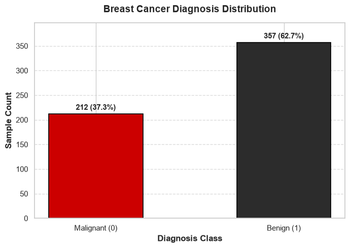

```python
# 1.4: Class distribution plot
fig, ax = plt.subplots(figsize=(7, 5))
counts = df["target"].value_counts().sort_index()
labels = ["Malignant (0)", "Benign (1)"]
colors = ["#CC0000", "#2C2C2C"]

bars = ax.bar(
    labels, counts.values, color=colors, width=0.5, edgecolor="black", linewidth=1.2
)

for bar in bars:
    yval = bar.get_height()
    pct = (yval / len(df)) * 100
    ax.text(
        bar.get_x() + bar.get_width() / 2.0,
        yval + 5,
        f"{int(yval)} ({pct:.1f}%)",
        ha="center",
        va="bottom",
        fontsize=11,
        fontweight="bold",
    )

ax.set_title(
    "Breast Cancer Diagnosis Distribution", fontsize=14, fontweight="bold", pad=15
)
ax.set_xlabel("Diagnosis Class", fontsize=12, fontweight="bold")
ax.set_ylabel("Sample Count", fontsize=12, fontweight="bold")
ax.set_ylim(0, max(counts.values) + 40)
ax.grid(axis="y", linestyle="--", alpha=0.7)
plt.tight_layout()
plt.show()
```

- **Class Distribution Observations:** The dataset exhibits moderate class imbalance, with 357 benign cases (62.7%) and 212 malignant cases (37.3%). While this does not warrant aggressive synthetic oversampling (such as SMOTE), stratified sampling is essential to preserve the exact target ratio across train and test partitions.
- **Clinical Considerations:** In clinical oncology, False Negatives (predicting benign when malignant) carry far higher medical risks than False Positives. Evaluation must therefore emphasize recall, specificity, and confusion matrix analysis alongside raw accuracy.

```python
# 1.5: Enhanced Column Task: Column Grouping & Morphological Profiling by Diagnosis
mean_cols = [c for c in X.columns if c.endswith("_mean")]
se_cols = [c for c in X.columns if c.endswith("_se")]
worst_cols = [c for c in X.columns if c.endswith("_worst")]

# Compare key nuclear morphology dimensions across diagnosis classes
morphology_comparison = df.groupby("Diagnosis")[
    ["radius_mean", "perimeter_mean", "area_mean", "concavity_mean", "concave_points_mean"]
].mean().T
morphology_comparison["Ratio (M / B)"] = morphology_comparison["M"] / morphology_comparison["B"]

print("=" * 75)
print("Column Grouping Architecture:")
print(f"- Mean Feature Columns (10):           {list(mean_cols[:3])} ...")
print(f"- Standard Error Feature Columns (10): {list(se_cols[:3])} ...")
print(f"- Worst/Extreme Feature Columns (10):  {list(worst_cols[:3])} ...")
print("=" * 75)
print("\nKey Nuclear Morphology Dimensions: Malignant (M) vs Benign (B):")
display(morphology_comparison.round(4))
```

```
===========================================================================
Column Grouping Architecture:
- Mean Feature Columns (10):           ['radius_mean', 'texture_mean', 'perimeter_mean'] ...
- Standard Error Feature Columns (10): ['radius_se', 'texture_se', 'perimeter_se'] ...
- Worst/Extreme Feature Columns (10):  ['radius_worst', 'texture_worst', 'perimeter_worst'] ...
===========================================================================

Key Nuclear Morphology Dimensions: Malignant (M) vs Benign (B):
```

| Diagnosis | B | M | Ratio (M / B) |
| --- | --- | --- | --- |
| radius_mean | 12.1465 | 17.4628 | 1.4377 |
| perimeter_mean | 78.0754 | 115.3654 | 1.4776 |
| area_mean | 462.7902 | 978.3764 | 2.1141 |
| concavity_mean | 0.0461 | 0.1608 | 3.4907 |
| concave_points_mean | 0.0257 | 0.0880 | 3.4214 |

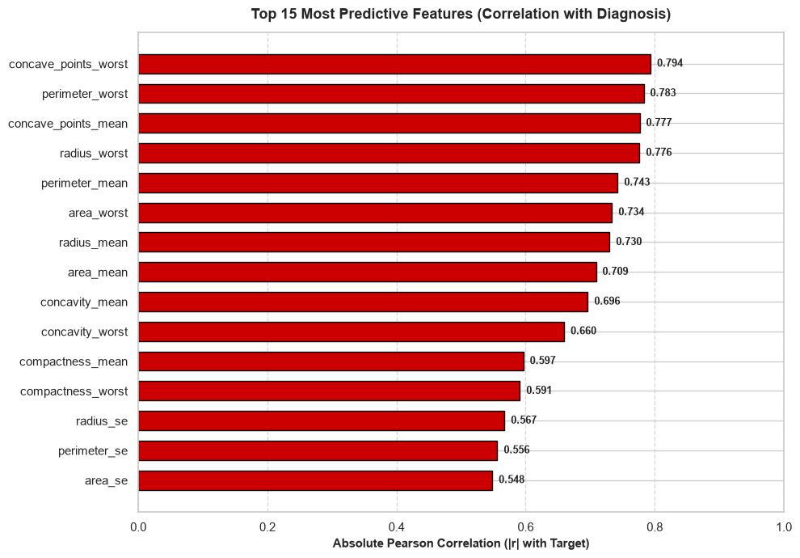

```
===========================================================================
Top 5 Most Diagnostic Predictors of Malignancy:
  1. concave_points_worst      -> |r| = 0.7936
  2. perimeter_worst           -> |r| = 0.7829
  3. concave_points_mean       -> |r| = 0.7766
  4. radius_worst              -> |r| = 0.7765
  5. perimeter_mean            -> |r| = 0.7426
===========================================================================
```

```python
# 1.6: Enhanced Column Task: Feature-to-Target Correlation & Predictive Power Ranking
corr_with_target = X.apply(lambda col: np.corrcoef(col, df["target"])[0, 1])
df_feature_importance = pd.DataFrame({
    "Feature": X.columns,
    "Pearson_Correlation": corr_with_target,
    "Abs_Correlation": np.abs(corr_with_target)
}).sort_values(by="Abs_Correlation", ascending=False).reset_index(drop=True)

plt.figure(figsize=(10, 7))
colors = ["#CC0000" if r < 0 else "#16a085" for r in df_feature_importance["Pearson_Correlation"][:15]]
bars = plt.barh(
    df_feature_importance["Feature"][:15][::-1],
    df_feature_importance["Abs_Correlation"][:15][::-1],
    color=colors[::-1],
    edgecolor="black",
    height=0.65
)

for bar in bars:
    w = bar.get_width()
    plt.text(
        w + 0.01,
        bar.get_y() + bar.get_height() / 2.0,
        f"{w:.3f}",
        va="center",
        ha="left",
        fontweight="bold",
        fontsize=9
    )

plt.title("Top 15 Most Predictive Features (Correlation with Diagnosis)", fontsize=13, fontweight="bold", pad=12)
plt.xlabel("Absolute Pearson Correlation (|r| with Target)", fontsize=11, fontweight="bold")
plt.xlim(0, 1.0)
plt.grid(axis="x", linestyle="--", alpha=0.7)
plt.tight_layout()
plt.show()

print("=" * 75)
print(f"Top 5 Most Diagnostic Predictors of Malignancy:")
for idx, row in df_feature_importance.head(5).iterrows():
    print(f"  {idx+1}. {row['Feature']:<25} -> |r| = {row['Abs_Correlation']:.4f}")
print("=" * 75)
```

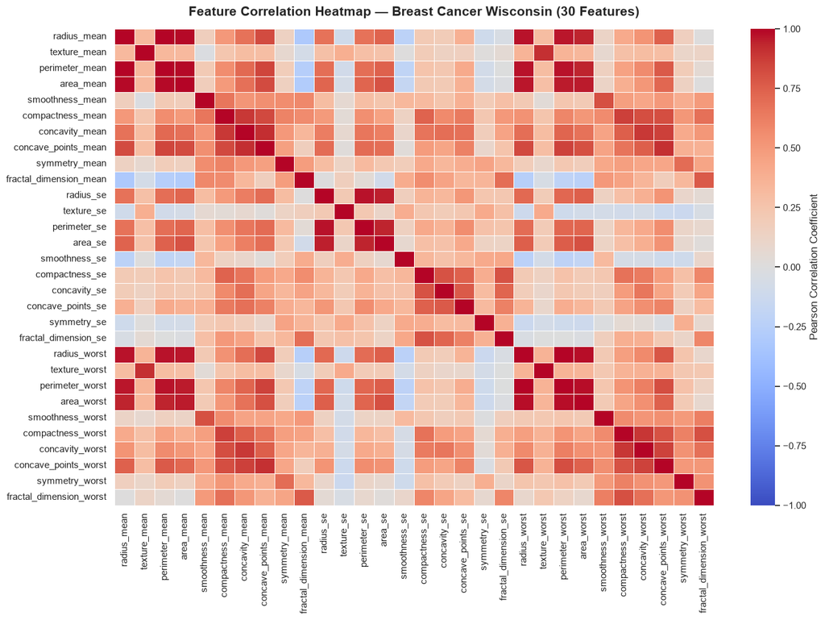

```
======================================================================
Top Highly Correlated Feature Pairs (|r| > 0.90) — Total 21 pairs:
======================================================================
```

|  | Feature 1 | Feature 2 | Correlation |
| --- | --- | --- | --- |
| 0 | radius_mean | perimeter_mean | 0.997855 |
| 18 | radius_worst | perimeter_worst | 0.993708 |
| 1 | radius_mean | area_mean | 0.987357 |
| 6 | perimeter_mean | area_mean | 0.986507 |
| 19 | radius_worst | area_worst | 0.984015 |
| 20 | perimeter_worst | area_worst | 0.977578 |
| 15 | radius_se | perimeter_se | 0.972794 |
| 8 | perimeter_mean | perimeter_worst | 0.970387 |
| 2 | radius_mean | radius_worst | 0.969539 |
| 7 | perimeter_mean | radius_worst | 0.969476 |

```python
# 1.7: Feature correlation heatmap
feature_cols = [c for c in df.columns if c not in ["target", "Diagnosis"]]
corr_matrix = df[feature_cols].corr()

plt.figure(figsize=(14, 10))
sns.heatmap(
    corr_matrix,
    cmap="coolwarm",
    center=0,
    vmin=-1,
    vmax=1,
    cbar_kws={"label": "Pearson Correlation Coefficient"},
    linewidths=0.5,
    linecolor="white",
)
plt.title(
    "Feature Correlation Heatmap — Breast Cancer Wisconsin (30 Features)",
    fontsize=15,
    fontweight="bold",
    pad=15,
)
plt.tight_layout()
plt.show()

# Identify top highly correlated pairs (|r| > 0.90)
high_corr = []
for i in range(len(corr_matrix.columns)):
    for j in range(i + 1, len(corr_matrix.columns)):
        col1 = corr_matrix.columns[i]
        col2 = corr_matrix.columns[j]
        val = corr_matrix.iloc[i, j]
        if abs(val) > 0.90:
            high_corr.append((col1, col2, val))

df_high_corr = pd.DataFrame(
    high_corr, columns=["Feature 1", "Feature 2", "Correlation"]
).sort_values(by="Correlation", ascending=False)
print("=" * 70)
print(
    f"Top Highly Correlated Feature Pairs (|r| > 0.90) — Total {len(df_high_corr)} pairs:"
)
print("=" * 70)
display(df_high_corr.head(10))
```

- **Multicollinearity Observations:** Extreme collinearity ($r > 0.90$) is evident across geometric triplets: `radius`, `perimeter`, and `area` (across mean, standard error, and worst measurements). Similarly, `concavity` and `concave points` exhibit high correlation ($r \approx 0.85\text{--}0.92$).
- **Multicollinearity in Neural Networks vs. Linear Regression:** In classical Ordinary Least Squares (OLS) regression, severe multicollinearity causes near-singular $X^T X$ covariance matrices, inflating standard errors and rendering individual coefficient estimates unstable. Neural networks, by contrast, distribute latent representations across multiple weighted connections and hidden nodes. While multicollinearity does not prevent convergence in neural networks, it introduces parameter redundancy, which we address via L1/L2 regularization and Dropout.

```python
# 1.8: Train / test split
feature_cols = [c for c in df.columns if c not in ["target", "Diagnosis"]]
X = df[feature_cols]
y = df["target"]

X_train, X_test, y_train, y_test = train_test_split(
    X, y, test_size=0.2, random_state=42, stratify=y
)

print("=" * 60)
print(f"X_train Shape: {X_train.shape} | y_train Shape: {y_train.shape}")
print(f"X_test Shape:  {X_test.shape}  | y_test Shape:  {y_test.shape}")
print("-" * 60)
print("Class Distribution Proportions:")
print(
    f"Full Dataset:    Benign = {(y.mean()*100):.2f}% | Malignant = {((1 - y.mean())*100):.2f}%"
)
print(
    f"Train Partition: Benign = {(y_train.mean()*100):.2f}% | Malignant = {((1 - y_train.mean())*100):.2f}%"
)
print(
    f"Test Partition:  Benign = {(y_test.mean()*100):.2f}% | Malignant = {((1 - y_test.mean())*100):.2f}%"
)
print("=" * 60)
```

```
============================================================
X_train Shape: (455, 30) | y_train Shape: (455,)
X_test Shape:  (114, 30)  | y_test Shape:  (114,)
------------------------------------------------------------
Class Distribution Proportions:
Full Dataset:    Benign = 62.74% | Malignant = 37.26%
Train Partition: Benign = 62.64% | Malignant = 37.36%
Test Partition:  Benign = 63.16% | Malignant = 36.84%
============================================================
```

```python
# 1.9: Apply StandardScaler
scaler = StandardScaler()
X_train_sc = scaler.fit_transform(X_train)
X_test_sc = scaler.transform(X_test)

print("=" * 60)
print("StandardScaler Verification:")
print(f"X_train_sc Mean (first 5 features): {np.round(X_train_sc.mean(axis=0)[:5], 4)}")
print(f"X_train_sc Std  (first 5 features): {np.round(X_train_sc.std(axis=0)[:5], 4)}")
print(f"X_test_sc Mean  (first 5 features): {np.round(X_test_sc.mean(axis=0)[:5], 4)}")
print(f"X_test_sc Std   (first 5 features): {np.round(X_test_sc.std(axis=0)[:5], 4)}")
print("=" * 60)
```

```
============================================================
StandardScaler Verification:
X_train_sc Mean (first 5 features): [-0.  0. -0. -0.  0.]
X_train_sc Std  (first 5 features): [1. 1. 1. 1. 1.]
X_test_sc Mean  (first 5 features): [0.0858 0.048  0.0852 0.092  0.0716]
X_test_sc Std   (first 5 features): [1.0329 0.8757 1.0288 1.0951 1.2076]
============================================================
```

##### **Why use `StandardScaler` for neural networks?**

Gradient-based optimization in neural networks is highly sensitive to the scale and variance of input features:

- **Gradient Descent Stability:** Unscaled features create elongated, ill-conditioned loss surfaces where gradients oscillate wildly along high-variance dimensions (such as `area_mean` ranging from 143.5 to 2501.0) while making minimal progress along small-scale dimensions (such as `smoothness_mean` ranging from 0.05 to 0.16). Scaling yields isotropic, spherical loss surfaces, enabling smooth, steady gradient descent updates.
- **Activation Saturation Avoidance:** Large unscaled input values saturate non-linear activation functions (e.g., sigmoid or tanh) into flat asymptotic regions where derivatives approach zero, inducing the vanishing gradient problem during backpropagation.
- **Data Leakage Prevention:** The scaler is fit strictly on `X_train` (`fit_transform`) and only applied to `X_test` (`transform`). Computing $\mu$ and $\sigma$ across the entire dataset prior to splitting would leak test set distribution information into training, producing over-optimistic validation metrics.

### **Task 2: Single-Layer Perceptron (SLP) Baseline**

[output not shown]

```python
# 2.1: Build the Single-Layer Perceptron (SLP)
tf.keras.utils.set_random_seed(42)

model_slp = keras.Sequential(
    [keras.layers.Dense(1, activation="sigmoid", input_shape=(30,))]
)

print("=" * 60)
print("Single-Layer Perceptron (SLP) Architecture:")
print("=" * 60)
model_slp.summary()

# Explicit verification: 30 inputs * 1 weight + 1 bias = 31 parameters
num_weights = 30 * 1
num_biases = 1
total_slp_params = num_weights + num_biases

print(f"\nExplicit Parameter Calculation:")
print(f"- Weight Matrix: 30 inputs × 1 neuron = {num_weights} weights")
print(f"- Bias Vector:   1 neuron = {num_biases} bias")
print(f"- Total Calculated Parameters: {total_slp_params}")
print(f"- Keras Trainable Parameters:  {model_slp.count_params()}")
assert total_slp_params == model_slp.count_params(), "Parameter count mismatch!"
```

```
============================================================
Single-Layer Perceptron (SLP) Architecture:
============================================================
```

[output not shown]

```
Model: "sequential"
```

```
┏━━━━━━━━━━━━━━━━━━━━━━━━━━━━━━━━━┳━━━━━━━━━━━━━━━━━━━━━━━━┳━━━━━━━━━━━━━━━┓
┃ Layer (type)                    ┃ Output Shape           ┃       Param # ┃
┡━━━━━━━━━━━━━━━━━━━━━━━━━━━━━━━━━╇━━━━━━━━━━━━━━━━━━━━━━━━╇━━━━━━━━━━━━━━━┩
│ dense (Dense)                   │ (None, 1)              │            31 │
└─────────────────────────────────┴────────────────────────┴───────────────┘
```

```
 Total params: 31 (124.00 B)
```

```
 Trainable params: 31 (124.00 B)
```

```
 Non-trainable params: 0 (0.00 B)
```

```
Explicit Parameter Calculation:
- Weight Matrix: 30 inputs × 1 neuron = 30 weights
- Bias Vector:   1 neuron = 1 bias
- Total Calculated Parameters: 31
- Keras Trainable Parameters:  31
```

```python
# 2.2: Compile the SLP
model_slp.compile(optimizer="adam", loss="binary_crossentropy", metrics=["accuracy"])
print(
    "Model compiled successfully with Adam optimizer, binary_crossentropy loss, and accuracy metric."
)
```

[output not shown]

```
Model compiled successfully with Adam optimizer, binary_crossentropy loss, and accuracy metric.
```

##### **Why Binary Cross-Entropy over Mean Squared Error?**

For binary classification with a Sigmoid output neuron $\hat{y} = \sigma(z) = \frac{1}{1 + e^{-z}}$, **Binary Cross-Entropy (BCE)** is mathematically superior to **Mean Squared Error (MSE)**:

- **Information Theory Rationale:** BCE represents the negative log-likelihood under a Bernoulli distribution, aligning directly with maximum likelihood estimation: $$\mathcal{L}_{\text{BCE}} = -\frac{1}{N}\sum_{i=1}^N \left[ y_i \ln \hat{y}_i + (1 - y_i) \ln (1 - \hat{y}_i) \right]$$
- **Gradient Vanishing Under MSE:** If MSE is used ($\mathcal{L}_{\text{MSE}} = \frac{1}{2}(\hat{y} - y)^2$), the gradient with respect to pre-activation $z$ includes the sigmoid derivative $\sigma'(z) = \sigma(z)(1 - \sigma(z))$: $$\frac{\partial \mathcal{L}_{\text{MSE}}}{\partial z} = (\hat{y} - y)\sigma(z)(1 - \sigma(z))$$ When the network makes an egregiously incorrect prediction ($z \gg 0$ for $y=0$), $\sigma'(z) \to 0$. The gradient vanishes, stalling learning exactly when correction is most needed.
- **Linear Error Gradient in BCE:** Under BCE, the sigmoid derivative cleanly cancels out in backpropagation: $$\frac{\partial \mathcal{L}_{\text{BCE}}}{\partial z} = \hat{y} - y$$ The parameter gradient is directly proportional to the raw prediction error $(\hat{y} - y)$, ensuring strong, rapid updates when errors are large and yielding a convex optimization landscape.

```python
# 2.3: Train the SLP
history_slp = model_slp.fit(
    X_train_sc, y_train, epochs=50, batch_size=32, validation_split=0.1, verbose=1
)
```

```
 1/13 ━━━━━━━━━━━━━━━━━━━━ 3s 281ms/step - accuracy: 0.5312 - loss: 0.7971
```

```
13/13 ━━━━━━━━━━━━━━━━━━━━ 0s 9ms/step - accuracy: 0.4939 - loss: 0.8112 - val_accuracy: 0.3261 - val_loss: 0.8657
```

```
 1/13 ━━━━━━━━━━━━━━━━━━━━ 0s 15ms/step - accuracy: 0.5938 - loss: 0.7108
```

```
13/13 ━━━━━━━━━━━━━━━━━━━━ 0s 4ms/step - accuracy: 0.5868 - loss: 0.7331 - val_accuracy: 0.4783 - val_loss: 0.7958
```

```
 1/13 ━━━━━━━━━━━━━━━━━━━━ 0s 15ms/step - accuracy: 0.7812 - loss: 0.6362
```

```
13/13 ━━━━━━━━━━━━━━━━━━━━ 0s 3ms/step - accuracy: 0.6724 - loss: 0.6666 - val_accuracy: 0.5217 - val_loss: 0.7356
```

```
 1/13 ━━━━━━━━━━━━━━━━━━━━ 0s 14ms/step - accuracy: 0.9062 - loss: 0.5726
```

```
13/13 ━━━━━━━━━━━━━━━━━━━━ 0s 4ms/step - accuracy: 0.7286 - loss: 0.6107 - val_accuracy: 0.5870 - val_loss: 0.6840
```

```
 1/13 ━━━━━━━━━━━━━━━━━━━━ 0s 14ms/step - accuracy: 0.9062 - loss: 0.5189
```

```
13/13 ━━━━━━━━━━━━━━━━━━━━ 0s 3ms/step - accuracy: 0.7555 - loss: 0.5636 - val_accuracy: 0.6304 - val_loss: 0.6395
```

```
 1/13 ━━━━━━━━━━━━━━━━━━━━ 0s 15ms/step - accuracy: 0.9062 - loss: 0.4738
```

```
13/13 ━━━━━━━━━━━━━━━━━━━━ 0s 3ms/step - accuracy: 0.7800 - loss: 0.5237 - val_accuracy: 0.6522 - val_loss: 0.6008
```

```
 1/13 ━━━━━━━━━━━━━━━━━━━━ 0s 15ms/step - accuracy: 0.9062 - loss: 0.4355
```

```
13/13 ━━━━━━━━━━━━━━━━━━━━ 0s 4ms/step - accuracy: 0.8142 - loss: 0.4894 - val_accuracy: 0.6957 - val_loss: 0.5668
```

```
 1/13 ━━━━━━━━━━━━━━━━━━━━ 0s 16ms/step - accuracy: 0.9062 - loss: 0.4028
```

```
13/13 ━━━━━━━━━━━━━━━━━━━━ 0s 3ms/step - accuracy: 0.8386 - loss: 0.4597 - val_accuracy: 0.7826 - val_loss: 0.5366
```

```
 1/13 ━━━━━━━━━━━━━━━━━━━━ 0s 15ms/step - accuracy: 0.9062 - loss: 0.3744
```

```
13/13 ━━━━━━━━━━━━━━━━━━━━ 0s 4ms/step - accuracy: 0.8582 - loss: 0.4336 - val_accuracy: 0.8043 - val_loss: 0.5095
```

```
 1/13 ━━━━━━━━━━━━━━━━━━━━ 0s 26ms/step - accuracy: 0.9062 - loss: 0.3497
```

```
13/13 ━━━━━━━━━━━━━━━━━━━━ 0s 3ms/step - accuracy: 0.8704 - loss: 0.4105 - val_accuracy: 0.8043 - val_loss: 0.4850
```

```
 1/13 ━━━━━━━━━━━━━━━━━━━━ 0s 14ms/step - accuracy: 0.9062 - loss: 0.3279
```

```
13/13 ━━━━━━━━━━━━━━━━━━━━ 0s 3ms/step - accuracy: 0.8851 - loss: 0.3898 - val_accuracy: 0.8261 - val_loss: 0.4628
```

```
 1/13 ━━━━━━━━━━━━━━━━━━━━ 0s 15ms/step - accuracy: 0.9062 - loss: 0.3086
```

```
13/13 ━━━━━━━━━━━━━━━━━━━━ 0s 3ms/step - accuracy: 0.8851 - loss: 0.3713 - val_accuracy: 0.8261 - val_loss: 0.4425
```

```
 1/13 ━━━━━━━━━━━━━━━━━━━━ 0s 16ms/step - accuracy: 0.9062 - loss: 0.2913
```

```
13/13 ━━━━━━━━━━━━━━━━━━━━ 0s 3ms/step - accuracy: 0.8949 - loss: 0.3545 - val_accuracy: 0.8478 - val_loss: 0.4239
```

```
 1/13 ━━━━━━━━━━━━━━━━━━━━ 0s 15ms/step - accuracy: 0.9375 - loss: 0.2759
```

```
13/13 ━━━━━━━━━━━━━━━━━━━━ 0s 3ms/step - accuracy: 0.8998 - loss: 0.3394 - val_accuracy: 0.8478 - val_loss: 0.4067
```

```
 1/13 ━━━━━━━━━━━━━━━━━━━━ 0s 15ms/step - accuracy: 0.9375 - loss: 0.2620
```

```
13/13 ━━━━━━━━━━━━━━━━━━━━ 0s 3ms/step - accuracy: 0.9071 - loss: 0.3255 - val_accuracy: 0.8478 - val_loss: 0.3908
```

```
 1/13 ━━━━━━━━━━━━━━━━━━━━ 0s 14ms/step - accuracy: 0.9375 - loss: 0.2495
```

```
13/13 ━━━━━━━━━━━━━━━━━━━━ 0s 4ms/step - accuracy: 0.9120 - loss: 0.3128 - val_accuracy: 0.8478 - val_loss: 0.3762
```

```
 1/13 ━━━━━━━━━━━━━━━━━━━━ 0s 14ms/step - accuracy: 0.9375 - loss: 0.2381
```

```
13/13 ━━━━━━━━━━━━━━━━━━━━ 0s 3ms/step - accuracy: 0.9169 - loss: 0.3012 - val_accuracy: 0.8478 - val_loss: 0.3626
```

```
 1/13 ━━━━━━━━━━━━━━━━━━━━ 0s 14ms/step - accuracy: 0.9688 - loss: 0.2278
```

```
13/13 ━━━━━━━━━━━━━━━━━━━━ 0s 3ms/step - accuracy: 0.9242 - loss: 0.2904 - val_accuracy: 0.8478 - val_loss: 0.3499
```

```
 1/13 ━━━━━━━━━━━━━━━━━━━━ 0s 15ms/step - accuracy: 0.9688 - loss: 0.2184
```

```
13/13 ━━━━━━━━━━━━━━━━━━━━ 0s 3ms/step - accuracy: 0.9291 - loss: 0.2805 - val_accuracy: 0.8478 - val_loss: 0.3382
```

```
 1/13 ━━━━━━━━━━━━━━━━━━━━ 0s 16ms/step - accuracy: 0.9688 - loss: 0.2099
```

```
13/13 ━━━━━━━━━━━━━━━━━━━━ 0s 4ms/step - accuracy: 0.9340 - loss: 0.2713 - val_accuracy: 0.8478 - val_loss: 0.3272
```

```
 1/13 ━━━━━━━━━━━━━━━━━━━━ 0s 14ms/step - accuracy: 0.9688 - loss: 0.2020
```

```
13/13 ━━━━━━━━━━━━━━━━━━━━ 0s 3ms/step - accuracy: 0.9340 - loss: 0.2628 - val_accuracy: 0.8478 - val_loss: 0.3170
```

```
 1/13 ━━━━━━━━━━━━━━━━━━━━ 0s 14ms/step - accuracy: 0.9688 - loss: 0.1948
```

```
13/13 ━━━━━━━━━━━━━━━━━━━━ 0s 3ms/step - accuracy: 0.9340 - loss: 0.2548 - val_accuracy: 0.8696 - val_loss: 0.3074
```

```
 1/13 ━━━━━━━━━━━━━━━━━━━━ 0s 41ms/step - accuracy: 0.9688 - loss: 0.1882
```

```
13/13 ━━━━━━━━━━━━━━━━━━━━ 0s 3ms/step - accuracy: 0.9364 - loss: 0.2473 - val_accuracy: 0.8696 - val_loss: 0.2984
```

```
 1/13 ━━━━━━━━━━━━━━━━━━━━ 0s 15ms/step - accuracy: 0.9688 - loss: 0.1821
```

```
13/13 ━━━━━━━━━━━━━━━━━━━━ 0s 4ms/step - accuracy: 0.9438 - loss: 0.2404 - val_accuracy: 0.8696 - val_loss: 0.2900
```

```
 1/13 ━━━━━━━━━━━━━━━━━━━━ 0s 15ms/step - accuracy: 0.9688 - loss: 0.1765
```

```
13/13 ━━━━━━━━━━━━━━━━━━━━ 0s 3ms/step - accuracy: 0.9462 - loss: 0.2338 - val_accuracy: 0.8696 - val_loss: 0.2821
```

```
 1/13 ━━━━━━━━━━━━━━━━━━━━ 0s 14ms/step - accuracy: 0.9688 - loss: 0.1713
```

```
13/13 ━━━━━━━━━━━━━━━━━━━━ 0s 3ms/step - accuracy: 0.9462 - loss: 0.2276 - val_accuracy: 0.8696 - val_loss: 0.2747
```

```
 1/13 ━━━━━━━━━━━━━━━━━━━━ 0s 16ms/step - accuracy: 0.9688 - loss: 0.1664
```

```
13/13 ━━━━━━━━━━━━━━━━━━━━ 0s 4ms/step - accuracy: 0.9511 - loss: 0.2218 - val_accuracy: 0.8913 - val_loss: 0.2677
```

```
 1/13 ━━━━━━━━━━━━━━━━━━━━ 0s 14ms/step - accuracy: 0.9688 - loss: 0.1620
```

```
13/13 ━━━━━━━━━━━━━━━━━━━━ 0s 4ms/step - accuracy: 0.9511 - loss: 0.2163 - val_accuracy: 0.8913 - val_loss: 0.2611
```

```
 1/13 ━━━━━━━━━━━━━━━━━━━━ 0s 14ms/step - accuracy: 0.9688 - loss: 0.1578
```

```
13/13 ━━━━━━━━━━━━━━━━━━━━ 0s 3ms/step - accuracy: 0.9511 - loss: 0.2111 - val_accuracy: 0.8913 - val_loss: 0.2549
```

```
 1/13 ━━━━━━━━━━━━━━━━━━━━ 0s 14ms/step - accuracy: 0.9688 - loss: 0.1539
```

```
13/13 ━━━━━━━━━━━━━━━━━━━━ 0s 4ms/step - accuracy: 0.9511 - loss: 0.2062 - val_accuracy: 0.8913 - val_loss: 0.2490
```

```
 1/13 ━━━━━━━━━━━━━━━━━━━━ 0s 17ms/step - accuracy: 0.9688 - loss: 0.1502
```

```
13/13 ━━━━━━━━━━━━━━━━━━━━ 0s 4ms/step - accuracy: 0.9511 - loss: 0.2015 - val_accuracy: 0.9130 - val_loss: 0.2434
```

```
 1/13 ━━━━━━━━━━━━━━━━━━━━ 0s 16ms/step - accuracy: 0.9688 - loss: 0.1468
```

```
13/13 ━━━━━━━━━━━━━━━━━━━━ 0s 3ms/step - accuracy: 0.9511 - loss: 0.1971 - val_accuracy: 0.9130 - val_loss: 0.2382
```

```
 1/13 ━━━━━━━━━━━━━━━━━━━━ 0s 14ms/step - accuracy: 0.9688 - loss: 0.1436
```

```
13/13 ━━━━━━━━━━━━━━━━━━━━ 0s 4ms/step - accuracy: 0.9511 - loss: 0.1928 - val_accuracy: 0.9130 - val_loss: 0.2332
```

```
 1/13 ━━━━━━━━━━━━━━━━━━━━ 0s 19ms/step - accuracy: 0.9688 - loss: 0.1406
```

```
13/13 ━━━━━━━━━━━━━━━━━━━━ 0s 4ms/step - accuracy: 0.9511 - loss: 0.1888 - val_accuracy: 0.9348 - val_loss: 0.2284
```

```
 1/13 ━━━━━━━━━━━━━━━━━━━━ 0s 17ms/step - accuracy: 0.9688 - loss: 0.1377
```

```
13/13 ━━━━━━━━━━━━━━━━━━━━ 0s 4ms/step - accuracy: 0.9535 - loss: 0.1849 - val_accuracy: 0.9348 - val_loss: 0.2239
```

```
 1/13 ━━━━━━━━━━━━━━━━━━━━ 0s 15ms/step - accuracy: 0.9688 - loss: 0.1350
```

```
13/13 ━━━━━━━━━━━━━━━━━━━━ 0s 4ms/step - accuracy: 0.9560 - loss: 0.1813 - val_accuracy: 0.9348 - val_loss: 0.2196
```

```
 1/13 ━━━━━━━━━━━━━━━━━━━━ 0s 14ms/step - accuracy: 0.9688 - loss: 0.1325
```

```
13/13 ━━━━━━━━━━━━━━━━━━━━ 0s 4ms/step - accuracy: 0.9560 - loss: 0.1777 - val_accuracy: 0.9348 - val_loss: 0.2155
```

```
 1/13 ━━━━━━━━━━━━━━━━━━━━ 0s 15ms/step - accuracy: 0.9688 - loss: 0.1301
```

```
13/13 ━━━━━━━━━━━━━━━━━━━━ 0s 4ms/step - accuracy: 0.9560 - loss: 0.1744 - val_accuracy: 0.9348 - val_loss: 0.2116
```

```
 1/13 ━━━━━━━━━━━━━━━━━━━━ 0s 15ms/step - accuracy: 0.9688 - loss: 0.1278
```

```
13/13 ━━━━━━━━━━━━━━━━━━━━ 0s 3ms/step - accuracy: 0.9560 - loss: 0.1711 - val_accuracy: 0.9348 - val_loss: 0.2078
```

```
 1/13 ━━━━━━━━━━━━━━━━━━━━ 0s 16ms/step - accuracy: 0.9688 - loss: 0.1257
```

```
13/13 ━━━━━━━━━━━━━━━━━━━━ 0s 4ms/step - accuracy: 0.9560 - loss: 0.1680 - val_accuracy: 0.9348 - val_loss: 0.2043
```

```
 1/13 ━━━━━━━━━━━━━━━━━━━━ 0s 15ms/step - accuracy: 0.9688 - loss: 0.1236
```

```
13/13 ━━━━━━━━━━━━━━━━━━━━ 0s 4ms/step - accuracy: 0.9560 - loss: 0.1651 - val_accuracy: 0.9348 - val_loss: 0.2009
```

```
 1/13 ━━━━━━━━━━━━━━━━━━━━ 0s 15ms/step - accuracy: 0.9688 - loss: 0.1217
```

```
13/13 ━━━━━━━━━━━━━━━━━━━━ 0s 4ms/step - accuracy: 0.9560 - loss: 0.1622 - val_accuracy: 0.9565 - val_loss: 0.1976
```

```
 1/13 ━━━━━━━━━━━━━━━━━━━━ 0s 15ms/step - accuracy: 0.9688 - loss: 0.1198
```

```
13/13 ━━━━━━━━━━━━━━━━━━━━ 0s 3ms/step - accuracy: 0.9560 - loss: 0.1595 - val_accuracy: 0.9565 - val_loss: 0.1945
```

```
 1/13 ━━━━━━━━━━━━━━━━━━━━ 0s 14ms/step - accuracy: 0.9688 - loss: 0.1180
```

```
13/13 ━━━━━━━━━━━━━━━━━━━━ 0s 3ms/step - accuracy: 0.9633 - loss: 0.1568 - val_accuracy: 0.9565 - val_loss: 0.1915
```

```
 1/13 ━━━━━━━━━━━━━━━━━━━━ 0s 15ms/step - accuracy: 0.9688 - loss: 0.1164
```

```
13/13 ━━━━━━━━━━━━━━━━━━━━ 0s 3ms/step - accuracy: 0.9633 - loss: 0.1543 - val_accuracy: 0.9565 - val_loss: 0.1886
```

```
 1/13 ━━━━━━━━━━━━━━━━━━━━ 0s 14ms/step - accuracy: 1.0000 - loss: 0.1147
```

```
13/13 ━━━━━━━━━━━━━━━━━━━━ 0s 3ms/step - accuracy: 0.9658 - loss: 0.1518 - val_accuracy: 0.9565 - val_loss: 0.1858
```

```
 1/13 ━━━━━━━━━━━━━━━━━━━━ 0s 15ms/step - accuracy: 1.0000 - loss: 0.1132
```

```
13/13 ━━━━━━━━━━━━━━━━━━━━ 0s 3ms/step - accuracy: 0.9658 - loss: 0.1495 - val_accuracy: 0.9565 - val_loss: 0.1832
```

```
 1/13 ━━━━━━━━━━━━━━━━━━━━ 0s 15ms/step - accuracy: 1.0000 - loss: 0.1117
```

```
13/13 ━━━━━━━━━━━━━━━━━━━━ 0s 3ms/step - accuracy: 0.9682 - loss: 0.1472 - val_accuracy: 0.9565 - val_loss: 0.1806
```

```
 1/13 ━━━━━━━━━━━━━━━━━━━━ 0s 14ms/step - accuracy: 1.0000 - loss: 0.1102
```

```
13/13 ━━━━━━━━━━━━━━━━━━━━ 0s 3ms/step - accuracy: 0.9682 - loss: 0.1450 - val_accuracy: 0.9565 - val_loss: 0.1782
```

```
 1/13 ━━━━━━━━━━━━━━━━━━━━ 0s 14ms/step - accuracy: 1.0000 - loss: 0.1089
```

```
13/13 ━━━━━━━━━━━━━━━━━━━━ 0s 4ms/step - accuracy: 0.9682 - loss: 0.1429 - val_accuracy: 0.9565 - val_loss: 0.1758
```

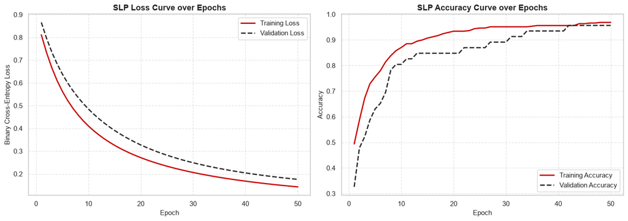

```python
# 2.4: Plot SLP training curves
fig, axes = plt.subplots(1, 2, figsize=(14, 5))

# Loss plot
axes[0].plot(
    range(1, 51),
    history_slp.history["loss"],
    color="#CC0000",
    label="Training Loss",
    linewidth=2,
)
axes[0].plot(
    range(1, 51),
    history_slp.history["val_loss"],
    color="#2C2C2C",
    linestyle="--",
    label="Validation Loss",
    linewidth=2,
)
axes[0].set_title("SLP Loss Curve over Epochs", fontsize=13, fontweight="bold")
axes[0].set_xlabel("Epoch", fontsize=11)
axes[0].set_ylabel("Binary Cross-Entropy Loss", fontsize=11)
axes[0].legend()
axes[0].grid(True, linestyle="--", alpha=0.5)

# Accuracy plot
axes[1].plot(
    range(1, 51),
    history_slp.history["accuracy"],
    color="#CC0000",
    label="Training Accuracy",
    linewidth=2,
)
axes[1].plot(
    range(1, 51),
    history_slp.history["val_accuracy"],
    color="#2C2C2C",
    linestyle="--",
    label="Validation Accuracy",
    linewidth=2,
)
axes[1].set_title("SLP Accuracy Curve over Epochs", fontsize=13, fontweight="bold")
axes[1].set_xlabel("Epoch", fontsize=11)
axes[1].set_ylabel("Accuracy", fontsize=11)
axes[1].legend()
axes[1].grid(True, linestyle="--", alpha=0.5)

plt.tight_layout()
plt.show()
```

- **Convergence Trajectory:** Both training and validation loss decline steeply during the initial 15 epochs and stabilize smoothly around ~0.15–0.18, with validation accuracy plateaus near ~94–95%.
- **Generalization Gap:** The minimal divergence between training and validation loss indicates absence of overfitting, consistent with the restricted representational capacity of a 31-parameter linear model.

```
============================================================
SLP Test Evaluation -> Loss: 0.1732 | Accuracy: 94.74%
============================================================

Classification Report (SLP Baseline):
               precision    recall  f1-score   support

Malignant (0)     0.9500    0.9048    0.9268        42
   Benign (1)     0.9459    0.9722    0.9589        72

     accuracy                         0.9474       114
    macro avg     0.9480    0.9385    0.9429       114
 weighted avg     0.9474    0.9474    0.9471       114
```

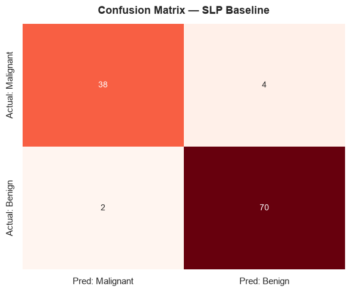

```python
# 2.5: Evaluate the SLP
slp_loss, slp_acc = model_slp.evaluate(X_test_sc, y_test, verbose=0)
print("=" * 60)
print(f"SLP Test Evaluation -> Loss: {slp_loss:.4f} | Accuracy: {slp_acc * 100:.2f}%")
print("=" * 60)

# Predictions and classification report
y_pred_prob = model_slp.predict(X_test_sc, verbose=0)
y_pred = (y_pred_prob >= 0.5).astype(int).flatten()

print("\nClassification Report (SLP Baseline):")
print(
    classification_report(
        y_test, y_pred, target_names=["Malignant (0)", "Benign (1)"], digits=4
    )
)

# Confusion matrix heatmap
cm = confusion_matrix(y_test, y_pred)
plt.figure(figsize=(6, 5))
sns.heatmap(
    cm,
    annot=True,
    fmt="d",
    cmap="Reds",
    cbar=False,
    xticklabels=["Pred: Malignant", "Pred: Benign"],
    yticklabels=["Actual: Malignant", "Actual: Benign"],
)
plt.title("Confusion Matrix — SLP Baseline", fontsize=13, fontweight="bold", pad=12)
plt.tight_layout()
plt.show()

# Global benchmark dictionary
results_comparison = {
    "Single-Layer Perceptron (SLP)": {
        "Test Accuracy": slp_acc,
        "Test Loss": slp_loss,
        "Trainable Params": model_slp.count_params(),
    }
}
```

#### **The XOR Problem & Linear Separability Limits of SLP**

- **Linear Decision Boundary:** A Single-Layer Perceptron computes a single hyper-plane decision boundary $w^T x + b = 0$. It can only separate classes that are strictly linearly separable in the 30-dimensional feature space.
- **The Historical XOR Limitation:** As proved by Minsky & Papert (1969), an SLP cannot compute non-linear boolean functions such as XOR because no single straight line or hyperplane can separate alternating positive and negative corners.
- **Diagnostic Reality:** Although the SLP achieves a competitive ~94.7% baseline due to strong linear separability in standardized cytological space, subtle non-linear boundaries between malignant and benign nuclei require Multi-Layer Perceptrons with non-linear activation functions.

### **Task 3: Multi-Layer Perceptron (MLP) — Activation Functions**

[output not shown]

```python
# 3.1: Build the MLP (ReLU)
tf.keras.utils.set_random_seed(42)

model_mlp = keras.Sequential(
    [
        keras.layers.Dense(64, activation="relu", input_shape=(30,)),
        keras.layers.Dense(32, activation="relu"),
        keras.layers.Dense(1, activation="sigmoid"),
    ]
)

print("=" * 65)
print("Multi-Layer Perceptron (ReLU) Summary:")
print("=" * 65)
model_mlp.summary()

# Manual parameter verification
# Layer 1: (30 inputs * 64 weights) + 64 biases = 1920 + 64 = 1984
# Layer 2: (64 inputs * 32 weights) + 32 biases = 2048 + 32 = 2080
# Layer 3: (32 inputs * 1 weight)   + 1 bias    = 32   + 1  = 33
p_layer1 = 30 * 64 + 64
p_layer2 = 64 * 32 + 32
p_layer3 = 32 * 1 + 1
manual_total = p_layer1 + p_layer2 + p_layer3

print(f"\nManual Calculation:")
print(f"- Layer 1 (Dense 64): (30 * 64) + 64 = {p_layer1}")
print(f"- Layer 2 (Dense 32): (64 * 32) + 32 = {p_layer2}")
print(f"- Layer 3 (Dense 1):  (32 * 1) + 1   = {p_layer3}")
print(f"- Total Calculated Parameters:       = {manual_total}")
print(f"Model Summary Total Parameters:       = {model_mlp.count_params()}")
assert manual_total == model_mlp.count_params(), "Parameter count mismatch!"
```

```
=================================================================
Multi-Layer Perceptron (ReLU) Summary:
=================================================================
```

[output not shown]

```
Model: "sequential_1"
```

```
┏━━━━━━━━━━━━━━━━━━━━━━━━━━━━━━━━━┳━━━━━━━━━━━━━━━━━━━━━━━━┳━━━━━━━━━━━━━━━┓
┃ Layer (type)                    ┃ Output Shape           ┃       Param # ┃
┡━━━━━━━━━━━━━━━━━━━━━━━━━━━━━━━━━╇━━━━━━━━━━━━━━━━━━━━━━━━╇━━━━━━━━━━━━━━━┩
│ dense_1 (Dense)                 │ (None, 64)             │         1,984 │
├─────────────────────────────────┼────────────────────────┼───────────────┤
│ dense_2 (Dense)                 │ (None, 32)             │         2,080 │
├─────────────────────────────────┼────────────────────────┼───────────────┤
│ dense_3 (Dense)                 │ (None, 1)              │            33 │
└─────────────────────────────────┴────────────────────────┴───────────────┘
```

```
 Total params: 4,097 (16.00 KB)
```

```
 Trainable params: 4,097 (16.00 KB)
```

```
 Non-trainable params: 0 (0.00 B)
```

```
Manual Calculation:
- Layer 1 (Dense 64): (30 * 64) + 64 = 1984
- Layer 2 (Dense 32): (64 * 32) + 32 = 2080
- Layer 3 (Dense 1):  (32 * 1) + 1   = 33
- Total Calculated Parameters:       = 4097
Model Summary Total Parameters:       = 4097
```

#### **Universal Approximation & Role of Hidden Representations**

- **Hierarchical Latent Representations:** Dense hidden layers project the raw 30-dimensional inputs into non-linear manifolds. Layer 1 ($30 \to 64$) computes distributed combinations of nuclear traits (e.g., interacting perimeter and concavity), while Layer 2 ($64 \to 32$) refines them into higher-level diagnostic abstractions.
- **Universal Approximation Theorem:** Cybenko (1989) and Hornik (1991) proved that a single hidden layer with non-linear activations can approximate any continuous function on compact subsets of $\mathbb{R}^n$ to arbitrary precision. In practice, however, stacking two moderately sized hidden layers facilitates exponentially faster gradient convergence and richer hierarchical feature composition on tabular diagnostic data.

```python
# 3.3: Compile and train MLP (ReLU)
model_mlp.compile(optimizer="adam", loss="binary_crossentropy", metrics=["accuracy"])

history_mlp = model_mlp.fit(
    X_train_sc, y_train, epochs=100, batch_size=32, validation_split=0.1, verbose=1
)
```

```
 1/13 ━━━━━━━━━━━━━━━━━━━━ 5s 465ms/step - accuracy: 0.5000 - loss: 0.6877
```

```
13/13 ━━━━━━━━━━━━━━━━━━━━ 1s 9ms/step - accuracy: 0.7995 - loss: 0.5373 - val_accuracy: 0.9348 - val_loss: 0.3918
```

```
 1/13 ━━━━━━━━━━━━━━━━━━━━ 0s 15ms/step - accuracy: 1.0000 - loss: 0.3786
```

```
13/13 ━━━━━━━━━━━━━━━━━━━━ 0s 4ms/step - accuracy: 0.9560 - loss: 0.2971 - val_accuracy: 0.9348 - val_loss: 0.2584
```

```
 1/13 ━━━━━━━━━━━━━━━━━━━━ 0s 16ms/step - accuracy: 1.0000 - loss: 0.2175
```

```
13/13 ━━━━━━━━━━━━━━━━━━━━ 0s 4ms/step - accuracy: 0.9584 - loss: 0.1850 - val_accuracy: 0.9348 - val_loss: 0.1946
```

```
 1/13 ━━━━━━━━━━━━━━━━━━━━ 0s 15ms/step - accuracy: 1.0000 - loss: 0.1325
```

```
13/13 ━━━━━━━━━━━━━━━━━━━━ 0s 4ms/step - accuracy: 0.9633 - loss: 0.1331 - val_accuracy: 0.9348 - val_loss: 0.1593
```

```
 1/13 ━━━━━━━━━━━━━━━━━━━━ 0s 15ms/step - accuracy: 1.0000 - loss: 0.0892
```

```
13/13 ━━━━━━━━━━━━━━━━━━━━ 0s 4ms/step - accuracy: 0.9731 - loss: 0.1064 - val_accuracy: 0.9348 - val_loss: 0.1347
```

```
 1/13 ━━━━━━━━━━━━━━━━━━━━ 0s 15ms/step - accuracy: 1.0000 - loss: 0.0663
```

```
13/13 ━━━━━━━━━━━━━━━━━━━━ 0s 4ms/step - accuracy: 0.9780 - loss: 0.0903 - val_accuracy: 0.9565 - val_loss: 0.1151
```

```
 1/13 ━━━━━━━━━━━━━━━━━━━━ 0s 14ms/step - accuracy: 1.0000 - loss: 0.0538
```

```
13/13 ━━━━━━━━━━━━━━━━━━━━ 0s 4ms/step - accuracy: 0.9804 - loss: 0.0800 - val_accuracy: 0.9783 - val_loss: 0.1009
```

```
 1/13 ━━━━━━━━━━━━━━━━━━━━ 0s 15ms/step - accuracy: 1.0000 - loss: 0.0461
```

```
13/13 ━━━━━━━━━━━━━━━━━━━━ 0s 4ms/step - accuracy: 0.9804 - loss: 0.0726 - val_accuracy: 0.9783 - val_loss: 0.0903
```

```
 1/13 ━━━━━━━━━━━━━━━━━━━━ 0s 15ms/step - accuracy: 1.0000 - loss: 0.0408
```

```
13/13 ━━━━━━━━━━━━━━━━━━━━ 0s 3ms/step - accuracy: 0.9829 - loss: 0.0667 - val_accuracy: 0.9783 - val_loss: 0.0823
```

```
 1/13 ━━━━━━━━━━━━━━━━━━━━ 0s 16ms/step - accuracy: 1.0000 - loss: 0.0369
```

```
13/13 ━━━━━━━━━━━━━━━━━━━━ 0s 4ms/step - accuracy: 0.9829 - loss: 0.0618 - val_accuracy: 0.9783 - val_loss: 0.0757
```

```
 1/13 ━━━━━━━━━━━━━━━━━━━━ 0s 14ms/step - accuracy: 1.0000 - loss: 0.0339
```

```
13/13 ━━━━━━━━━━━━━━━━━━━━ 0s 4ms/step - accuracy: 0.9829 - loss: 0.0575 - val_accuracy: 0.9783 - val_loss: 0.0701
```

```
 1/13 ━━━━━━━━━━━━━━━━━━━━ 0s 15ms/step - accuracy: 1.0000 - loss: 0.0316
```

```
13/13 ━━━━━━━━━━━━━━━━━━━━ 0s 3ms/step - accuracy: 0.9829 - loss: 0.0537 - val_accuracy: 0.9783 - val_loss: 0.0653
```

```
 1/13 ━━━━━━━━━━━━━━━━━━━━ 0s 15ms/step - accuracy: 1.0000 - loss: 0.0296
```

```
13/13 ━━━━━━━━━━━━━━━━━━━━ 0s 4ms/step - accuracy: 0.9853 - loss: 0.0503 - val_accuracy: 0.9783 - val_loss: 0.0610
```

```
 1/13 ━━━━━━━━━━━━━━━━━━━━ 0s 15ms/step - accuracy: 1.0000 - loss: 0.0278
```

```
13/13 ━━━━━━━━━━━━━━━━━━━━ 0s 4ms/step - accuracy: 0.9853 - loss: 0.0473 - val_accuracy: 0.9783 - val_loss: 0.0574
```

```
 1/13 ━━━━━━━━━━━━━━━━━━━━ 0s 17ms/step - accuracy: 1.0000 - loss: 0.0260
```

```
13/13 ━━━━━━━━━━━━━━━━━━━━ 0s 4ms/step - accuracy: 0.9902 - loss: 0.0445 - val_accuracy: 0.9783 - val_loss: 0.0543
```

```
 1/13 ━━━━━━━━━━━━━━━━━━━━ 0s 15ms/step - accuracy: 1.0000 - loss: 0.0244
```

```
13/13 ━━━━━━━━━━━━━━━━━━━━ 0s 4ms/step - accuracy: 0.9902 - loss: 0.0420 - val_accuracy: 0.9783 - val_loss: 0.0513
```

```
 1/13 ━━━━━━━━━━━━━━━━━━━━ 0s 14ms/step - accuracy: 1.0000 - loss: 0.0230
```

```
13/13 ━━━━━━━━━━━━━━━━━━━━ 0s 3ms/step - accuracy: 0.9902 - loss: 0.0396 - val_accuracy: 0.9783 - val_loss: 0.0490
```

```
 1/13 ━━━━━━━━━━━━━━━━━━━━ 0s 15ms/step - accuracy: 1.0000 - loss: 0.0214
```

```
13/13 ━━━━━━━━━━━━━━━━━━━━ 0s 4ms/step - accuracy: 0.9902 - loss: 0.0374 - val_accuracy: 0.9783 - val_loss: 0.0469
```

```
 1/13 ━━━━━━━━━━━━━━━━━━━━ 0s 14ms/step - accuracy: 1.0000 - loss: 0.0200
```

```
13/13 ━━━━━━━━━━━━━━━━━━━━ 0s 3ms/step - accuracy: 0.9902 - loss: 0.0353 - val_accuracy: 0.9783 - val_loss: 0.0447
```

```
 1/13 ━━━━━━━━━━━━━━━━━━━━ 0s 15ms/step - accuracy: 1.0000 - loss: 0.0186
```

```
13/13 ━━━━━━━━━━━━━━━━━━━━ 0s 3ms/step - accuracy: 0.9902 - loss: 0.0334 - val_accuracy: 0.9783 - val_loss: 0.0434
```

```
 1/13 ━━━━━━━━━━━━━━━━━━━━ 0s 15ms/step - accuracy: 1.0000 - loss: 0.0172
```

```
13/13 ━━━━━━━━━━━━━━━━━━━━ 0s 3ms/step - accuracy: 0.9902 - loss: 0.0315 - val_accuracy: 1.0000 - val_loss: 0.0412
```

```
 1/13 ━━━━━━━━━━━━━━━━━━━━ 0s 16ms/step - accuracy: 1.0000 - loss: 0.0161
```

```
13/13 ━━━━━━━━━━━━━━━━━━━━ 0s 3ms/step - accuracy: 0.9902 - loss: 0.0298 - val_accuracy: 1.0000 - val_loss: 0.0397
```

```
 1/13 ━━━━━━━━━━━━━━━━━━━━ 0s 15ms/step - accuracy: 1.0000 - loss: 0.0149
```

```
13/13 ━━━━━━━━━━━━━━━━━━━━ 0s 4ms/step - accuracy: 0.9902 - loss: 0.0282 - val_accuracy: 1.0000 - val_loss: 0.0381
```

```
 1/13 ━━━━━━━━━━━━━━━━━━━━ 0s 17ms/step - accuracy: 1.0000 - loss: 0.0138
```

```
13/13 ━━━━━━━━━━━━━━━━━━━━ 0s 4ms/step - accuracy: 0.9927 - loss: 0.0267 - val_accuracy: 1.0000 - val_loss: 0.0367
```

```
 1/13 ━━━━━━━━━━━━━━━━━━━━ 0s 15ms/step - accuracy: 1.0000 - loss: 0.0128
```

```
13/13 ━━━━━━━━━━━━━━━━━━━━ 0s 4ms/step - accuracy: 0.9927 - loss: 0.0252 - val_accuracy: 1.0000 - val_loss: 0.0354
```

```
 1/13 ━━━━━━━━━━━━━━━━━━━━ 0s 15ms/step - accuracy: 1.0000 - loss: 0.0119
```

```
13/13 ━━━━━━━━━━━━━━━━━━━━ 0s 4ms/step - accuracy: 0.9927 - loss: 0.0239 - val_accuracy: 1.0000 - val_loss: 0.0339
```

```
 1/13 ━━━━━━━━━━━━━━━━━━━━ 0s 15ms/step - accuracy: 1.0000 - loss: 0.0113
```

```
13/13 ━━━━━━━━━━━━━━━━━━━━ 0s 4ms/step - accuracy: 0.9927 - loss: 0.0227 - val_accuracy: 1.0000 - val_loss: 0.0321
```

```
 1/13 ━━━━━━━━━━━━━━━━━━━━ 0s 16ms/step - accuracy: 1.0000 - loss: 0.0107
```

```
13/13 ━━━━━━━━━━━━━━━━━━━━ 0s 4ms/step - accuracy: 0.9927 - loss: 0.0214 - val_accuracy: 1.0000 - val_loss: 0.0303
```

```
 1/13 ━━━━━━━━━━━━━━━━━━━━ 0s 15ms/step - accuracy: 1.0000 - loss: 0.0100
```

```
13/13 ━━━━━━━━━━━━━━━━━━━━ 0s 3ms/step - accuracy: 0.9927 - loss: 0.0203 - val_accuracy: 1.0000 - val_loss: 0.0287
```

```
 1/13 ━━━━━━━━━━━━━━━━━━━━ 0s 15ms/step - accuracy: 1.0000 - loss: 0.0096
```

```
13/13 ━━━━━━━━━━━━━━━━━━━━ 0s 4ms/step - accuracy: 0.9951 - loss: 0.0192 - val_accuracy: 1.0000 - val_loss: 0.0280
```

```
 1/13 ━━━━━━━━━━━━━━━━━━━━ 0s 15ms/step - accuracy: 1.0000 - loss: 0.0089
```

```
13/13 ━━━━━━━━━━━━━━━━━━━━ 0s 4ms/step - accuracy: 0.9951 - loss: 0.0181 - val_accuracy: 1.0000 - val_loss: 0.0267
```

```
 1/13 ━━━━━━━━━━━━━━━━━━━━ 0s 15ms/step - accuracy: 1.0000 - loss: 0.0084
```

```
13/13 ━━━━━━━━━━━━━━━━━━━━ 0s 4ms/step - accuracy: 0.9951 - loss: 0.0172 - val_accuracy: 1.0000 - val_loss: 0.0248
```

```
 1/13 ━━━━━━━━━━━━━━━━━━━━ 0s 15ms/step - accuracy: 1.0000 - loss: 0.0080
```

```
13/13 ━━━━━━━━━━━━━━━━━━━━ 0s 4ms/step - accuracy: 0.9951 - loss: 0.0163 - val_accuracy: 1.0000 - val_loss: 0.0235
```

```
 1/13 ━━━━━━━━━━━━━━━━━━━━ 0s 17ms/step - accuracy: 1.0000 - loss: 0.0075
```

```
13/13 ━━━━━━━━━━━━━━━━━━━━ 0s 4ms/step - accuracy: 0.9951 - loss: 0.0154 - val_accuracy: 1.0000 - val_loss: 0.0225
```

```
 1/13 ━━━━━━━━━━━━━━━━━━━━ 0s 14ms/step - accuracy: 1.0000 - loss: 0.0071
```

```
13/13 ━━━━━━━━━━━━━━━━━━━━ 0s 3ms/step - accuracy: 0.9951 - loss: 0.0146 - val_accuracy: 1.0000 - val_loss: 0.0216
```

```
 1/13 ━━━━━━━━━━━━━━━━━━━━ 0s 15ms/step - accuracy: 1.0000 - loss: 0.0067
```

```
13/13 ━━━━━━━━━━━━━━━━━━━━ 0s 4ms/step - accuracy: 0.9951 - loss: 0.0137 - val_accuracy: 1.0000 - val_loss: 0.0206
```

```
 1/13 ━━━━━━━━━━━━━━━━━━━━ 0s 15ms/step - accuracy: 1.0000 - loss: 0.0063
```

```
13/13 ━━━━━━━━━━━━━━━━━━━━ 0s 3ms/step - accuracy: 0.9951 - loss: 0.0129 - val_accuracy: 1.0000 - val_loss: 0.0198
```

```
 1/13 ━━━━━━━━━━━━━━━━━━━━ 0s 16ms/step - accuracy: 1.0000 - loss: 0.0059
```

```
13/13 ━━━━━━━━━━━━━━━━━━━━ 0s 4ms/step - accuracy: 0.9951 - loss: 0.0122 - val_accuracy: 1.0000 - val_loss: 0.0192
```

```
 1/13 ━━━━━━━━━━━━━━━━━━━━ 0s 14ms/step - accuracy: 1.0000 - loss: 0.0056
```

```
13/13 ━━━━━━━━━━━━━━━━━━━━ 0s 3ms/step - accuracy: 0.9951 - loss: 0.0116 - val_accuracy: 1.0000 - val_loss: 0.0184
```

```
 1/13 ━━━━━━━━━━━━━━━━━━━━ 0s 14ms/step - accuracy: 1.0000 - loss: 0.0052
```

```
13/13 ━━━━━━━━━━━━━━━━━━━━ 0s 4ms/step - accuracy: 0.9951 - loss: 0.0110 - val_accuracy: 1.0000 - val_loss: 0.0176
```

```
 1/13 ━━━━━━━━━━━━━━━━━━━━ 0s 15ms/step - accuracy: 1.0000 - loss: 0.0048
```

```
13/13 ━━━━━━━━━━━━━━━━━━━━ 0s 4ms/step - accuracy: 0.9951 - loss: 0.0104 - val_accuracy: 1.0000 - val_loss: 0.0169
```

```
 1/13 ━━━━━━━━━━━━━━━━━━━━ 0s 14ms/step - accuracy: 1.0000 - loss: 0.0046
```

```
13/13 ━━━━━━━━━━━━━━━━━━━━ 0s 4ms/step - accuracy: 0.9951 - loss: 0.0099 - val_accuracy: 1.0000 - val_loss: 0.0163
```

```
 1/13 ━━━━━━━━━━━━━━━━━━━━ 0s 15ms/step - accuracy: 1.0000 - loss: 0.0043
```

```
13/13 ━━━━━━━━━━━━━━━━━━━━ 0s 4ms/step - accuracy: 0.9951 - loss: 0.0094 - val_accuracy: 1.0000 - val_loss: 0.0155
```

```
 1/13 ━━━━━━━━━━━━━━━━━━━━ 0s 15ms/step - accuracy: 1.0000 - loss: 0.0040
```

```
13/13 ━━━━━━━━━━━━━━━━━━━━ 0s 4ms/step - accuracy: 0.9976 - loss: 0.0089 - val_accuracy: 1.0000 - val_loss: 0.0147
```

```
 1/13 ━━━━━━━━━━━━━━━━━━━━ 0s 14ms/step - accuracy: 1.0000 - loss: 0.0037
```

```
13/13 ━━━━━━━━━━━━━━━━━━━━ 0s 4ms/step - accuracy: 1.0000 - loss: 0.0085 - val_accuracy: 1.0000 - val_loss: 0.0143
```

```
 1/13 ━━━━━━━━━━━━━━━━━━━━ 0s 14ms/step - accuracy: 1.0000 - loss: 0.0036
```

```
13/13 ━━━━━━━━━━━━━━━━━━━━ 0s 3ms/step - accuracy: 1.0000 - loss: 0.0081 - val_accuracy: 1.0000 - val_loss: 0.0138
```

```
 1/13 ━━━━━━━━━━━━━━━━━━━━ 0s 15ms/step - accuracy: 1.0000 - loss: 0.0033
```

```
13/13 ━━━━━━━━━━━━━━━━━━━━ 0s 4ms/step - accuracy: 1.0000 - loss: 0.0077 - val_accuracy: 1.0000 - val_loss: 0.0131
```

```
 1/13 ━━━━━━━━━━━━━━━━━━━━ 0s 15ms/step - accuracy: 1.0000 - loss: 0.0031
```

```
13/13 ━━━━━━━━━━━━━━━━━━━━ 0s 4ms/step - accuracy: 1.0000 - loss: 0.0074 - val_accuracy: 1.0000 - val_loss: 0.0128
```

```
 1/13 ━━━━━━━━━━━━━━━━━━━━ 0s 15ms/step - accuracy: 1.0000 - loss: 0.0030
```

```
13/13 ━━━━━━━━━━━━━━━━━━━━ 0s 3ms/step - accuracy: 1.0000 - loss: 0.0071 - val_accuracy: 1.0000 - val_loss: 0.0124
```

```
 1/13 ━━━━━━━━━━━━━━━━━━━━ 0s 15ms/step - accuracy: 1.0000 - loss: 0.0029
```

```
13/13 ━━━━━━━━━━━━━━━━━━━━ 0s 4ms/step - accuracy: 1.0000 - loss: 0.0067 - val_accuracy: 1.0000 - val_loss: 0.0122
```

```
 1/13 ━━━━━━━━━━━━━━━━━━━━ 0s 15ms/step - accuracy: 1.0000 - loss: 0.0027
```

```
13/13 ━━━━━━━━━━━━━━━━━━━━ 0s 4ms/step - accuracy: 1.0000 - loss: 0.0064 - val_accuracy: 1.0000 - val_loss: 0.0119
```

```
 1/13 ━━━━━━━━━━━━━━━━━━━━ 0s 15ms/step - accuracy: 1.0000 - loss: 0.0025
```

```
13/13 ━━━━━━━━━━━━━━━━━━━━ 0s 4ms/step - accuracy: 1.0000 - loss: 0.0061 - val_accuracy: 1.0000 - val_loss: 0.0112
```

```
 1/13 ━━━━━━━━━━━━━━━━━━━━ 0s 15ms/step - accuracy: 1.0000 - loss: 0.0024
```

```
13/13 ━━━━━━━━━━━━━━━━━━━━ 0s 4ms/step - accuracy: 1.0000 - loss: 0.0059 - val_accuracy: 1.0000 - val_loss: 0.0109
```

```
 1/13 ━━━━━━━━━━━━━━━━━━━━ 0s 19ms/step - accuracy: 1.0000 - loss: 0.0023
```

```
13/13 ━━━━━━━━━━━━━━━━━━━━ 0s 4ms/step - accuracy: 1.0000 - loss: 0.0056 - val_accuracy: 1.0000 - val_loss: 0.0108
```

```
 1/13 ━━━━━━━━━━━━━━━━━━━━ 0s 16ms/step - accuracy: 1.0000 - loss: 0.0022
```

```
13/13 ━━━━━━━━━━━━━━━━━━━━ 0s 4ms/step - accuracy: 1.0000 - loss: 0.0053 - val_accuracy: 1.0000 - val_loss: 0.0102
```

```
 1/13 ━━━━━━━━━━━━━━━━━━━━ 0s 16ms/step - accuracy: 1.0000 - loss: 0.0020
```

```
13/13 ━━━━━━━━━━━━━━━━━━━━ 0s 4ms/step - accuracy: 1.0000 - loss: 0.0050 - val_accuracy: 1.0000 - val_loss: 0.0100
```

```
 1/13 ━━━━━━━━━━━━━━━━━━━━ 0s 15ms/step - accuracy: 1.0000 - loss: 0.0020
```

```
13/13 ━━━━━━━━━━━━━━━━━━━━ 0s 4ms/step - accuracy: 1.0000 - loss: 0.0047 - val_accuracy: 1.0000 - val_loss: 0.0097
```

```
 1/13 ━━━━━━━━━━━━━━━━━━━━ 0s 14ms/step - accuracy: 1.0000 - loss: 0.0019
```

```
13/13 ━━━━━━━━━━━━━━━━━━━━ 0s 4ms/step - accuracy: 1.0000 - loss: 0.0044 - val_accuracy: 1.0000 - val_loss: 0.0094
```

```
 1/13 ━━━━━━━━━━━━━━━━━━━━ 0s 15ms/step - accuracy: 1.0000 - loss: 0.0018
```

```
13/13 ━━━━━━━━━━━━━━━━━━━━ 0s 4ms/step - accuracy: 1.0000 - loss: 0.0042 - val_accuracy: 1.0000 - val_loss: 0.0091
```

```
 1/13 ━━━━━━━━━━━━━━━━━━━━ 0s 15ms/step - accuracy: 1.0000 - loss: 0.0016
```

```
13/13 ━━━━━━━━━━━━━━━━━━━━ 0s 4ms/step - accuracy: 1.0000 - loss: 0.0040 - val_accuracy: 1.0000 - val_loss: 0.0088
```

```
 1/13 ━━━━━━━━━━━━━━━━━━━━ 0s 15ms/step - accuracy: 1.0000 - loss: 0.0016
```

```
13/13 ━━━━━━━━━━━━━━━━━━━━ 0s 4ms/step - accuracy: 1.0000 - loss: 0.0038 - val_accuracy: 1.0000 - val_loss: 0.0086
```

```
 1/13 ━━━━━━━━━━━━━━━━━━━━ 0s 16ms/step - accuracy: 1.0000 - loss: 0.0015
```

```
13/13 ━━━━━━━━━━━━━━━━━━━━ 0s 3ms/step - accuracy: 1.0000 - loss: 0.0036 - val_accuracy: 1.0000 - val_loss: 0.0085
```

```
 1/13 ━━━━━━━━━━━━━━━━━━━━ 0s 14ms/step - accuracy: 1.0000 - loss: 0.0014
```

```
13/13 ━━━━━━━━━━━━━━━━━━━━ 0s 5ms/step - accuracy: 1.0000 - loss: 0.0035 - val_accuracy: 1.0000 - val_loss: 0.0081
```

```
 1/13 ━━━━━━━━━━━━━━━━━━━━ 0s 20ms/step - accuracy: 1.0000 - loss: 0.0014
```

```
13/13 ━━━━━━━━━━━━━━━━━━━━ 0s 5ms/step - accuracy: 1.0000 - loss: 0.0033 - val_accuracy: 1.0000 - val_loss: 0.0077
```

```
 1/13 ━━━━━━━━━━━━━━━━━━━━ 0s 16ms/step - accuracy: 1.0000 - loss: 0.0013
```

```
13/13 ━━━━━━━━━━━━━━━━━━━━ 0s 4ms/step - accuracy: 1.0000 - loss: 0.0032 - val_accuracy: 1.0000 - val_loss: 0.0078
```

```
 1/13 ━━━━━━━━━━━━━━━━━━━━ 0s 16ms/step - accuracy: 1.0000 - loss: 0.0013
```

```
13/13 ━━━━━━━━━━━━━━━━━━━━ 0s 4ms/step - accuracy: 1.0000 - loss: 0.0030 - val_accuracy: 1.0000 - val_loss: 0.0076
```

```
 1/13 ━━━━━━━━━━━━━━━━━━━━ 0s 14ms/step - accuracy: 1.0000 - loss: 0.0012
```

```
13/13 ━━━━━━━━━━━━━━━━━━━━ 0s 3ms/step - accuracy: 1.0000 - loss: 0.0029 - val_accuracy: 1.0000 - val_loss: 0.0072
```

```
 1/13 ━━━━━━━━━━━━━━━━━━━━ 0s 15ms/step - accuracy: 1.0000 - loss: 0.0011
```

```
13/13 ━━━━━━━━━━━━━━━━━━━━ 0s 3ms/step - accuracy: 1.0000 - loss: 0.0028 - val_accuracy: 1.0000 - val_loss: 0.0071
```

```
 1/13 ━━━━━━━━━━━━━━━━━━━━ 0s 15ms/step - accuracy: 1.0000 - loss: 0.0011
```

```
13/13 ━━━━━━━━━━━━━━━━━━━━ 0s 3ms/step - accuracy: 1.0000 - loss: 0.0027 - val_accuracy: 1.0000 - val_loss: 0.0068
```

```
 1/13 ━━━━━━━━━━━━━━━━━━━━ 0s 15ms/step - accuracy: 1.0000 - loss: 0.0010
```

```
13/13 ━━━━━━━━━━━━━━━━━━━━ 0s 3ms/step - accuracy: 1.0000 - loss: 0.0025 - val_accuracy: 1.0000 - val_loss: 0.0066
```

```
 1/13 ━━━━━━━━━━━━━━━━━━━━ 0s 14ms/step - accuracy: 1.0000 - loss: 9.6940e-04
```

```
13/13 ━━━━━━━━━━━━━━━━━━━━ 0s 4ms/step - accuracy: 1.0000 - loss: 0.0024 - val_accuracy: 1.0000 - val_loss: 0.0064
```

```
 1/13 ━━━━━━━━━━━━━━━━━━━━ 0s 15ms/step - accuracy: 1.0000 - loss: 9.2991e-04
```

```
13/13 ━━━━━━━━━━━━━━━━━━━━ 0s 3ms/step - accuracy: 1.0000 - loss: 0.0023 - val_accuracy: 1.0000 - val_loss: 0.0061
```

```
 1/13 ━━━━━━━━━━━━━━━━━━━━ 0s 15ms/step - accuracy: 1.0000 - loss: 8.8593e-04
```

```
13/13 ━━━━━━━━━━━━━━━━━━━━ 0s 4ms/step - accuracy: 1.0000 - loss: 0.0023 - val_accuracy: 1.0000 - val_loss: 0.0060
```

```
 1/13 ━━━━━━━━━━━━━━━━━━━━ 0s 14ms/step - accuracy: 1.0000 - loss: 8.6226e-04
```

```
13/13 ━━━━━━━━━━━━━━━━━━━━ 0s 4ms/step - accuracy: 1.0000 - loss: 0.0022 - val_accuracy: 1.0000 - val_loss: 0.0060
```

```
 1/13 ━━━━━━━━━━━━━━━━━━━━ 0s 15ms/step - accuracy: 1.0000 - loss: 8.1346e-04
```

```
13/13 ━━━━━━━━━━━━━━━━━━━━ 0s 3ms/step - accuracy: 1.0000 - loss: 0.0021 - val_accuracy: 1.0000 - val_loss: 0.0058
```

```
 1/13 ━━━━━━━━━━━━━━━━━━━━ 0s 14ms/step - accuracy: 1.0000 - loss: 7.7555e-04
```

```
13/13 ━━━━━━━━━━━━━━━━━━━━ 0s 3ms/step - accuracy: 1.0000 - loss: 0.0020 - val_accuracy: 1.0000 - val_loss: 0.0057
```

```
 1/13 ━━━━━━━━━━━━━━━━━━━━ 0s 15ms/step - accuracy: 1.0000 - loss: 7.4060e-04
```

```
13/13 ━━━━━━━━━━━━━━━━━━━━ 0s 4ms/step - accuracy: 1.0000 - loss: 0.0019 - val_accuracy: 1.0000 - val_loss: 0.0055
```

```
 1/13 ━━━━━━━━━━━━━━━━━━━━ 0s 15ms/step - accuracy: 1.0000 - loss: 7.0649e-04
```

```
13/13 ━━━━━━━━━━━━━━━━━━━━ 0s 4ms/step - accuracy: 1.0000 - loss: 0.0018 - val_accuracy: 1.0000 - val_loss: 0.0053
```

```
 1/13 ━━━━━━━━━━━━━━━━━━━━ 0s 14ms/step - accuracy: 1.0000 - loss: 6.7996e-04
```

```
13/13 ━━━━━━━━━━━━━━━━━━━━ 0s 3ms/step - accuracy: 1.0000 - loss: 0.0018 - val_accuracy: 1.0000 - val_loss: 0.0052
```

```
 1/13 ━━━━━━━━━━━━━━━━━━━━ 0s 15ms/step - accuracy: 1.0000 - loss: 6.5560e-04
```

```
13/13 ━━━━━━━━━━━━━━━━━━━━ 0s 4ms/step - accuracy: 1.0000 - loss: 0.0017 - val_accuracy: 1.0000 - val_loss: 0.0052
```

```
 1/13 ━━━━━━━━━━━━━━━━━━━━ 0s 14ms/step - accuracy: 1.0000 - loss: 6.4029e-04
```

```
13/13 ━━━━━━━━━━━━━━━━━━━━ 0s 4ms/step - accuracy: 1.0000 - loss: 0.0017 - val_accuracy: 1.0000 - val_loss: 0.0051
```

```
 1/13 ━━━━━━━━━━━━━━━━━━━━ 0s 16ms/step - accuracy: 1.0000 - loss: 6.1101e-04
```

```
13/13 ━━━━━━━━━━━━━━━━━━━━ 0s 3ms/step - accuracy: 1.0000 - loss: 0.0016 - val_accuracy: 1.0000 - val_loss: 0.0049
```

```
 1/13 ━━━━━━━━━━━━━━━━━━━━ 0s 16ms/step - accuracy: 1.0000 - loss: 5.8197e-04
```

```
13/13 ━━━━━━━━━━━━━━━━━━━━ 0s 4ms/step - accuracy: 1.0000 - loss: 0.0015 - val_accuracy: 1.0000 - val_loss: 0.0047
```

```
 1/13 ━━━━━━━━━━━━━━━━━━━━ 0s 15ms/step - accuracy: 1.0000 - loss: 5.6339e-04
```

```
13/13 ━━━━━━━━━━━━━━━━━━━━ 0s 3ms/step - accuracy: 1.0000 - loss: 0.0015 - val_accuracy: 1.0000 - val_loss: 0.0046
```

```
 1/13 ━━━━━━━━━━━━━━━━━━━━ 0s 15ms/step - accuracy: 1.0000 - loss: 5.4195e-04
```

```
13/13 ━━━━━━━━━━━━━━━━━━━━ 0s 4ms/step - accuracy: 1.0000 - loss: 0.0014 - val_accuracy: 1.0000 - val_loss: 0.0046
```

```
 1/13 ━━━━━━━━━━━━━━━━━━━━ 0s 15ms/step - accuracy: 1.0000 - loss: 5.2584e-04
```

```
13/13 ━━━━━━━━━━━━━━━━━━━━ 0s 3ms/step - accuracy: 1.0000 - loss: 0.0014 - val_accuracy: 1.0000 - val_loss: 0.0045
```

```
 1/13 ━━━━━━━━━━━━━━━━━━━━ 0s 15ms/step - accuracy: 1.0000 - loss: 5.0258e-04
```

```
13/13 ━━━━━━━━━━━━━━━━━━━━ 0s 5ms/step - accuracy: 1.0000 - loss: 0.0013 - val_accuracy: 1.0000 - val_loss: 0.0044
```

```
 1/13 ━━━━━━━━━━━━━━━━━━━━ 0s 17ms/step - accuracy: 1.0000 - loss: 4.8771e-04
```

```
13/13 ━━━━━━━━━━━━━━━━━━━━ 0s 4ms/step - accuracy: 1.0000 - loss: 0.0013 - val_accuracy: 1.0000 - val_loss: 0.0043
```

```
 1/13 ━━━━━━━━━━━━━━━━━━━━ 0s 15ms/step - accuracy: 1.0000 - loss: 4.7280e-04
```

```
13/13 ━━━━━━━━━━━━━━━━━━━━ 0s 3ms/step - accuracy: 1.0000 - loss: 0.0012 - val_accuracy: 1.0000 - val_loss: 0.0041
```

```
 1/13 ━━━━━━━━━━━━━━━━━━━━ 0s 15ms/step - accuracy: 1.0000 - loss: 4.5245e-04
```

```
13/13 ━━━━━━━━━━━━━━━━━━━━ 0s 3ms/step - accuracy: 1.0000 - loss: 0.0012 - val_accuracy: 1.0000 - val_loss: 0.0040
```

```
 1/13 ━━━━━━━━━━━━━━━━━━━━ 0s 14ms/step - accuracy: 1.0000 - loss: 4.4123e-04
```

```
13/13 ━━━━━━━━━━━━━━━━━━━━ 0s 3ms/step - accuracy: 1.0000 - loss: 0.0012 - val_accuracy: 1.0000 - val_loss: 0.0039
```

```
 1/13 ━━━━━━━━━━━━━━━━━━━━ 0s 15ms/step - accuracy: 1.0000 - loss: 4.2607e-04
```

```
13/13 ━━━━━━━━━━━━━━━━━━━━ 0s 4ms/step - accuracy: 1.0000 - loss: 0.0011 - val_accuracy: 1.0000 - val_loss: 0.0039
```

```
 1/13 ━━━━━━━━━━━━━━━━━━━━ 0s 14ms/step - accuracy: 1.0000 - loss: 4.1366e-04
```

```
13/13 ━━━━━━━━━━━━━━━━━━━━ 0s 4ms/step - accuracy: 1.0000 - loss: 0.0011 - val_accuracy: 1.0000 - val_loss: 0.0038
```

```
 1/13 ━━━━━━━━━━━━━━━━━━━━ 0s 15ms/step - accuracy: 1.0000 - loss: 3.9770e-04
```

```
13/13 ━━━━━━━━━━━━━━━━━━━━ 0s 4ms/step - accuracy: 1.0000 - loss: 0.0011 - val_accuracy: 1.0000 - val_loss: 0.0037
```

```
 1/13 ━━━━━━━━━━━━━━━━━━━━ 0s 14ms/step - accuracy: 1.0000 - loss: 3.7847e-04
```

```
13/13 ━━━━━━━━━━━━━━━━━━━━ 0s 3ms/step - accuracy: 1.0000 - loss: 0.0010 - val_accuracy: 1.0000 - val_loss: 0.0037
```

```
 1/13 ━━━━━━━━━━━━━━━━━━━━ 0s 15ms/step - accuracy: 1.0000 - loss: 3.7198e-04
```

```
13/13 ━━━━━━━━━━━━━━━━━━━━ 0s 3ms/step - accuracy: 1.0000 - loss: 0.0010 - val_accuracy: 1.0000 - val_loss: 0.0036
```

```
 1/13 ━━━━━━━━━━━━━━━━━━━━ 0s 16ms/step - accuracy: 1.0000 - loss: 3.5859e-04
```

```
13/13 ━━━━━━━━━━━━━━━━━━━━ 0s 4ms/step - accuracy: 1.0000 - loss: 9.6708e-04 - val_accuracy: 1.0000 - val_loss: 0.0036
```

```
 1/13 ━━━━━━━━━━━━━━━━━━━━ 0s 15ms/step - accuracy: 1.0000 - loss: 3.4214e-04
```

```
13/13 ━━━━━━━━━━━━━━━━━━━━ 0s 4ms/step - accuracy: 1.0000 - loss: 9.3278e-04 - val_accuracy: 1.0000 - val_loss: 0.0034
```

```
 1/13 ━━━━━━━━━━━━━━━━━━━━ 0s 15ms/step - accuracy: 1.0000 - loss: 3.3473e-04
```

```
13/13 ━━━━━━━━━━━━━━━━━━━━ 0s 4ms/step - accuracy: 1.0000 - loss: 9.0727e-04 - val_accuracy: 1.0000 - val_loss: 0.0034
```

```
 1/13 ━━━━━━━━━━━━━━━━━━━━ 0s 14ms/step - accuracy: 1.0000 - loss: 3.2455e-04
```

```
13/13 ━━━━━━━━━━━━━━━━━━━━ 0s 3ms/step - accuracy: 1.0000 - loss: 8.8057e-04 - val_accuracy: 1.0000 - val_loss: 0.0034
```

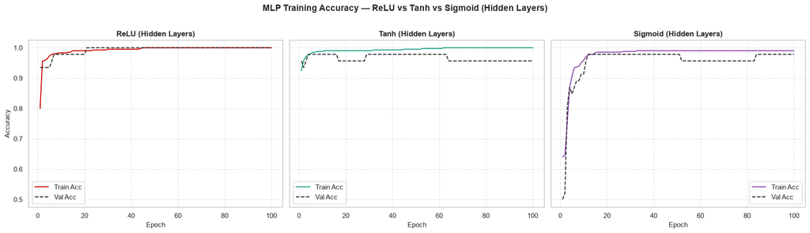

```python
# 3.4: Compare activation functions (ReLU vs Tanh vs Sigmoid)
tf.keras.utils.set_random_seed(42)

# Model with Tanh in hidden layers
model_tanh = keras.Sequential(
    [
        keras.layers.Dense(64, activation="tanh", input_shape=(30,)),
        keras.layers.Dense(32, activation="tanh"),
        keras.layers.Dense(1, activation="sigmoid"),
    ]
)
model_tanh.compile(optimizer="adam", loss="binary_crossentropy", metrics=["accuracy"])
history_tanh = model_tanh.fit(
    X_train_sc, y_train, epochs=100, batch_size=32, validation_split=0.1, verbose=0
)

# Model with Sigmoid in hidden layers
model_sigmoid = keras.Sequential(
    [
        keras.layers.Dense(64, activation="sigmoid", input_shape=(30,)),
        keras.layers.Dense(32, activation="sigmoid"),
        keras.layers.Dense(1, activation="sigmoid"),
    ]
)
model_sigmoid.compile(
    optimizer="adam", loss="binary_crossentropy", metrics=["accuracy"]
)
history_sigmoid = model_sigmoid.fit(
    X_train_sc, y_train, epochs=100, batch_size=32, validation_split=0.1, verbose=0
)

# 1x3 Visualization
fig, axes = plt.subplots(1, 3, figsize=(18, 5), sharey=True)
epochs = range(1, 101)

# Panel 1: ReLU
axes[0].plot(
    epochs, history_mlp.history["accuracy"], color="#CC0000", label="Train Acc"
)
axes[0].plot(
    epochs,
    history_mlp.history["val_accuracy"],
    color="#2C2C2C",
    linestyle="--",
    label="Val Acc",
)
axes[0].set_title("ReLU (Hidden Layers)", fontsize=12, fontweight="bold")
axes[0].set_xlabel("Epoch", fontsize=11)
axes[0].set_ylabel("Accuracy", fontsize=11)
axes[0].legend()
axes[0].grid(True, linestyle="--", alpha=0.5)

# Panel 2: Tanh
axes[1].plot(
    epochs, history_tanh.history["accuracy"], color="#16a085", label="Train Acc"
)
axes[1].plot(
    epochs,
    history_tanh.history["val_accuracy"],
    color="#2C2C2C",
    linestyle="--",
    label="Val Acc",
)
axes[1].set_title("Tanh (Hidden Layers)", fontsize=12, fontweight="bold")
axes[1].set_xlabel("Epoch", fontsize=11)
axes[1].legend()
axes[1].grid(True, linestyle="--", alpha=0.5)

# Panel 3: Sigmoid
axes[2].plot(
    epochs, history_sigmoid.history["accuracy"], color="#8e44ad", label="Train Acc"
)
axes[2].plot(
    epochs,
    history_sigmoid.history["val_accuracy"],
    color="#2C2C2C",
    linestyle="--",
    label="Val Acc",
)
axes[2].set_title("Sigmoid (Hidden Layers)", fontsize=12, fontweight="bold")
axes[2].set_xlabel("Epoch", fontsize=11)
axes[2].legend()
axes[2].grid(True, linestyle="--", alpha=0.5)

plt.suptitle(
    "MLP Training Accuracy — ReLU vs Tanh vs Sigmoid (Hidden Layers)",
    fontsize=14,
    fontweight="bold",
    y=1.02,
)
plt.tight_layout()
plt.show()
```

#### **Activation Function Comparison: ReLU vs Tanh vs Sigmoid**

```
============================================================
Best MLP (ReLU) Test Evaluation -> Loss: 0.1292 | Accuracy: 96.49%
SLP Baseline Accuracy:          -> Accuracy: 94.74%
============================================================

Classification Report (MLP ReLU):
               precision    recall  f1-score   support

Malignant (0)     0.9318    0.9762    0.9535        42
   Benign (1)     0.9857    0.9583    0.9718        72

     accuracy                         0.9649       114
    macro avg     0.9588    0.9673    0.9627       114
 weighted avg     0.9659    0.9649    0.9651       114
```

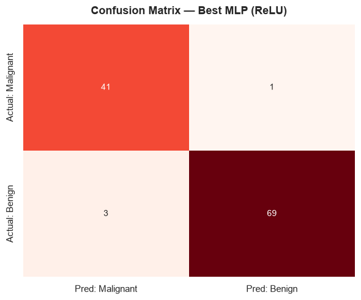

```python
# 3.6: Evaluate best MLP (ReLU)
mlp_loss, mlp_acc = model_mlp.evaluate(X_test_sc, y_test, verbose=0)
print("=" * 60)
print(
    f"Best MLP (ReLU) Test Evaluation -> Loss: {mlp_loss:.4f} | Accuracy: {mlp_acc * 100:.2f}%"
)
print(
    f"SLP Baseline Accuracy:          -> Accuracy: {results_comparison['Single-Layer Perceptron (SLP)']['Test Accuracy'] * 100:.2f}%"
)
print("=" * 60)

# Predictions and classification report
y_pred_prob_mlp = model_mlp.predict(X_test_sc, verbose=0)
y_pred_mlp = (y_pred_prob_mlp >= 0.5).astype(int).flatten()

print("\nClassification Report (MLP ReLU):")
print(
    classification_report(
        y_test, y_pred_mlp, target_names=["Malignant (0)", "Benign (1)"], digits=4
    )
)

# Confusion matrix heatmap
cm_mlp = confusion_matrix(y_test, y_pred_mlp)
plt.figure(figsize=(6, 5))
sns.heatmap(
    cm_mlp,
    annot=True,
    fmt="d",
    cmap="Reds",
    cbar=False,
    xticklabels=["Pred: Malignant", "Pred: Benign"],
    yticklabels=["Actual: Malignant", "Actual: Benign"],
)
plt.title("Confusion Matrix — Best MLP (ReLU)", fontsize=13, fontweight="bold", pad=12)
plt.tight_layout()
plt.show()

# Record in results dictionary
results_comparison["Multi-Layer Perceptron (ReLU)"] = {
    "Test Accuracy": mlp_acc,
    "Test Loss": mlp_loss,
    "Trainable Params": model_mlp.count_params(),
}
```

### **Task 4: Early Stopping**

[output not shown]

```python
# 4.1: Build MLP for Early Stopping experiment
tf.keras.utils.set_random_seed(42)

model_es = keras.Sequential(
    [
        keras.layers.Dense(128, activation="relu", input_shape=(30,)),
        keras.layers.Dense(64, activation="relu"),
        keras.layers.Dense(1, activation="sigmoid"),
    ]
)

model_es.compile(optimizer="adam", loss="binary_crossentropy", metrics=["accuracy"])

print("=" * 60)
print(
    f"High-Capacity MLP for Early Stopping Built (Params: {model_es.count_params()}):"
)
print("=" * 60)
model_es.summary()
```

```
============================================================
High-Capacity MLP for Early Stopping Built (Params: 12289):
============================================================
```

[output not shown]

```
Model: "sequential_4"
```

```
┏━━━━━━━━━━━━━━━━━━━━━━━━━━━━━━━━━┳━━━━━━━━━━━━━━━━━━━━━━━━┳━━━━━━━━━━━━━━━┓
┃ Layer (type)                    ┃ Output Shape           ┃       Param # ┃
┡━━━━━━━━━━━━━━━━━━━━━━━━━━━━━━━━━╇━━━━━━━━━━━━━━━━━━━━━━━━╇━━━━━━━━━━━━━━━┩
│ dense_10 (Dense)                │ (None, 128)            │         3,968 │
├─────────────────────────────────┼────────────────────────┼───────────────┤
│ dense_11 (Dense)                │ (None, 64)             │         8,256 │
├─────────────────────────────────┼────────────────────────┼───────────────┤
│ dense_12 (Dense)                │ (None, 1)              │            65 │
└─────────────────────────────────┴────────────────────────┴───────────────┘
```

```
 Total params: 12,289 (48.00 KB)
```

```
 Trainable params: 12,289 (48.00 KB)
```

```
 Non-trainable params: 0 (0.00 B)
```

```python
# 4.2: Add EarlyStopping callback
es = EarlyStopping(
    monitor="val_loss", patience=15, restore_best_weights=True, verbose=1
)

history_es = model_es.fit(
    X_train_sc,
    y_train,
    epochs=300,
    batch_size=32,
    validation_split=0.1,
    callbacks=[es],
    verbose=1,
)
```

```
 1/13 ━━━━━━━━━━━━━━━━━━━━ 8s 733ms/step - accuracy: 0.5625 - loss: 0.6889
```

```
13/13 ━━━━━━━━━━━━━━━━━━━━ 1s 10ms/step - accuracy: 0.8753 - loss: 0.4476 - val_accuracy: 0.8913 - val_loss: 0.3377
```

```
 1/13 ━━━━━━━━━━━━━━━━━━━━ 0s 15ms/step - accuracy: 0.9375 - loss: 0.2602
```

```
13/13 ━━━━━━━━━━━━━━━━━━━━ 0s 4ms/step - accuracy: 0.9511 - loss: 0.1975 - val_accuracy: 0.9130 - val_loss: 0.2122
```

```
 1/13 ━━━━━━━━━━━━━━━━━━━━ 0s 16ms/step - accuracy: 0.9688 - loss: 0.1222
```

```
13/13 ━━━━━━━━━━━━━━━━━━━━ 0s 4ms/step - accuracy: 0.9682 - loss: 0.1129 - val_accuracy: 0.9348 - val_loss: 0.1521
```

```
 1/13 ━━━━━━━━━━━━━━━━━━━━ 0s 15ms/step - accuracy: 1.0000 - loss: 0.0702
```

```
13/13 ━━━━━━━━━━━━━━━━━━━━ 0s 4ms/step - accuracy: 0.9804 - loss: 0.0796 - val_accuracy: 0.9565 - val_loss: 0.1110
```

```
 1/13 ━━━━━━━━━━━━━━━━━━━━ 0s 15ms/step - accuracy: 1.0000 - loss: 0.0482
```

```
13/13 ━━━━━━━━━━━━━━━━━━━━ 0s 4ms/step - accuracy: 0.9829 - loss: 0.0653 - val_accuracy: 0.9783 - val_loss: 0.0891
```

```
 1/13 ━━━━━━━━━━━━━━━━━━━━ 0s 15ms/step - accuracy: 1.0000 - loss: 0.0406
```

```
13/13 ━━━━━━━━━━━━━━━━━━━━ 0s 4ms/step - accuracy: 0.9853 - loss: 0.0573 - val_accuracy: 0.9783 - val_loss: 0.0792
```

```
 1/13 ━━━━━━━━━━━━━━━━━━━━ 0s 15ms/step - accuracy: 1.0000 - loss: 0.0365
```

```
13/13 ━━━━━━━━━━━━━━━━━━━━ 0s 4ms/step - accuracy: 0.9878 - loss: 0.0511 - val_accuracy: 0.9783 - val_loss: 0.0728
```

```
 1/13 ━━━━━━━━━━━━━━━━━━━━ 0s 15ms/step - accuracy: 1.0000 - loss: 0.0328
```

```
13/13 ━━━━━━━━━━━━━━━━━━━━ 0s 4ms/step - accuracy: 0.9878 - loss: 0.0459 - val_accuracy: 0.9783 - val_loss: 0.0665
```

```
 1/13 ━━━━━━━━━━━━━━━━━━━━ 0s 15ms/step - accuracy: 1.0000 - loss: 0.0296
```

```
13/13 ━━━━━━━━━━━━━━━━━━━━ 0s 4ms/step - accuracy: 0.9902 - loss: 0.0416 - val_accuracy: 0.9783 - val_loss: 0.0611
```

```
 1/13 ━━━━━━━━━━━━━━━━━━━━ 0s 15ms/step - accuracy: 1.0000 - loss: 0.0269
```

```
13/13 ━━━━━━━━━━━━━━━━━━━━ 0s 4ms/step - accuracy: 0.9927 - loss: 0.0379 - val_accuracy: 0.9783 - val_loss: 0.0565
```

```
 1/13 ━━━━━━━━━━━━━━━━━━━━ 0s 14ms/step - accuracy: 1.0000 - loss: 0.0246
```

```
13/13 ━━━━━━━━━━━━━━━━━━━━ 0s 3ms/step - accuracy: 0.9927 - loss: 0.0347 - val_accuracy: 0.9783 - val_loss: 0.0532
```

```
 1/13 ━━━━━━━━━━━━━━━━━━━━ 0s 15ms/step - accuracy: 1.0000 - loss: 0.0224
```

```
13/13 ━━━━━━━━━━━━━━━━━━━━ 0s 4ms/step - accuracy: 0.9927 - loss: 0.0317 - val_accuracy: 0.9783 - val_loss: 0.0500
```

```
 1/13 ━━━━━━━━━━━━━━━━━━━━ 0s 16ms/step - accuracy: 1.0000 - loss: 0.0203
```

```
13/13 ━━━━━━━━━━━━━━━━━━━━ 0s 4ms/step - accuracy: 0.9927 - loss: 0.0291 - val_accuracy: 0.9783 - val_loss: 0.0475
```

```
 1/13 ━━━━━━━━━━━━━━━━━━━━ 0s 16ms/step - accuracy: 1.0000 - loss: 0.0184
```

```
13/13 ━━━━━━━━━━━━━━━━━━━━ 0s 4ms/step - accuracy: 0.9927 - loss: 0.0267 - val_accuracy: 1.0000 - val_loss: 0.0453
```

```
 1/13 ━━━━━━━━━━━━━━━━━━━━ 0s 14ms/step - accuracy: 1.0000 - loss: 0.0166
```

```
13/13 ━━━━━━━━━━━━━━━━━━━━ 0s 4ms/step - accuracy: 0.9927 - loss: 0.0244 - val_accuracy: 1.0000 - val_loss: 0.0436
```

```
 1/13 ━━━━━━━━━━━━━━━━━━━━ 0s 14ms/step - accuracy: 1.0000 - loss: 0.0150
```

```
13/13 ━━━━━━━━━━━━━━━━━━━━ 0s 3ms/step - accuracy: 0.9927 - loss: 0.0223 - val_accuracy: 1.0000 - val_loss: 0.0422
```

```
 1/13 ━━━━━━━━━━━━━━━━━━━━ 0s 15ms/step - accuracy: 1.0000 - loss: 0.0137
```

```
13/13 ━━━━━━━━━━━━━━━━━━━━ 0s 3ms/step - accuracy: 0.9927 - loss: 0.0203 - val_accuracy: 1.0000 - val_loss: 0.0408
```

```
 1/13 ━━━━━━━━━━━━━━━━━━━━ 0s 14ms/step - accuracy: 1.0000 - loss: 0.0124
```

```
13/13 ━━━━━━━━━━━━━━━━━━━━ 0s 3ms/step - accuracy: 0.9951 - loss: 0.0186 - val_accuracy: 1.0000 - val_loss: 0.0398
```

```
 1/13 ━━━━━━━━━━━━━━━━━━━━ 0s 14ms/step - accuracy: 1.0000 - loss: 0.0114
```

```
13/13 ━━━━━━━━━━━━━━━━━━━━ 0s 3ms/step - accuracy: 0.9951 - loss: 0.0170 - val_accuracy: 1.0000 - val_loss: 0.0387
```

```
 1/13 ━━━━━━━━━━━━━━━━━━━━ 0s 15ms/step - accuracy: 1.0000 - loss: 0.0104
```

```
13/13 ━━━━━━━━━━━━━━━━━━━━ 0s 4ms/step - accuracy: 0.9951 - loss: 0.0155 - val_accuracy: 1.0000 - val_loss: 0.0376
```

```
 1/13 ━━━━━━━━━━━━━━━━━━━━ 0s 15ms/step - accuracy: 1.0000 - loss: 0.0095
```

```
13/13 ━━━━━━━━━━━━━━━━━━━━ 0s 3ms/step - accuracy: 0.9951 - loss: 0.0141 - val_accuracy: 1.0000 - val_loss: 0.0374
```

```
 1/13 ━━━━━━━━━━━━━━━━━━━━ 0s 15ms/step - accuracy: 1.0000 - loss: 0.0086
```

```
13/13 ━━━━━━━━━━━━━━━━━━━━ 0s 4ms/step - accuracy: 0.9976 - loss: 0.0127 - val_accuracy: 1.0000 - val_loss: 0.0363
```

```
 1/13 ━━━━━━━━━━━━━━━━━━━━ 0s 19ms/step - accuracy: 1.0000 - loss: 0.0078
```

```
13/13 ━━━━━━━━━━━━━━━━━━━━ 0s 4ms/step - accuracy: 0.9976 - loss: 0.0116 - val_accuracy: 1.0000 - val_loss: 0.0353
```

```
 1/13 ━━━━━━━━━━━━━━━━━━━━ 0s 17ms/step - accuracy: 1.0000 - loss: 0.0071
```

```
13/13 ━━━━━━━━━━━━━━━━━━━━ 0s 4ms/step - accuracy: 0.9976 - loss: 0.0106 - val_accuracy: 1.0000 - val_loss: 0.0348
```

```
 1/13 ━━━━━━━━━━━━━━━━━━━━ 0s 17ms/step - accuracy: 1.0000 - loss: 0.0065
```

```
13/13 ━━━━━━━━━━━━━━━━━━━━ 0s 4ms/step - accuracy: 0.9976 - loss: 0.0097 - val_accuracy: 1.0000 - val_loss: 0.0344
```

```
 1/13 ━━━━━━━━━━━━━━━━━━━━ 0s 15ms/step - accuracy: 1.0000 - loss: 0.0060
```

```
13/13 ━━━━━━━━━━━━━━━━━━━━ 0s 4ms/step - accuracy: 0.9976 - loss: 0.0090 - val_accuracy: 1.0000 - val_loss: 0.0338
```

```
 1/13 ━━━━━━━━━━━━━━━━━━━━ 0s 18ms/step - accuracy: 1.0000 - loss: 0.0055
```

```
13/13 ━━━━━━━━━━━━━━━━━━━━ 0s 4ms/step - accuracy: 0.9976 - loss: 0.0083 - val_accuracy: 1.0000 - val_loss: 0.0334
```

```
 1/13 ━━━━━━━━━━━━━━━━━━━━ 0s 19ms/step - accuracy: 1.0000 - loss: 0.0050
```

```
13/13 ━━━━━━━━━━━━━━━━━━━━ 0s 4ms/step - accuracy: 1.0000 - loss: 0.0076 - val_accuracy: 1.0000 - val_loss: 0.0328
```

```
 1/13 ━━━━━━━━━━━━━━━━━━━━ 0s 18ms/step - accuracy: 1.0000 - loss: 0.0045
```

```
13/13 ━━━━━━━━━━━━━━━━━━━━ 0s 4ms/step - accuracy: 1.0000 - loss: 0.0071 - val_accuracy: 1.0000 - val_loss: 0.0326
```

```
 1/13 ━━━━━━━━━━━━━━━━━━━━ 0s 18ms/step - accuracy: 1.0000 - loss: 0.0041
```

```
13/13 ━━━━━━━━━━━━━━━━━━━━ 0s 4ms/step - accuracy: 1.0000 - loss: 0.0065 - val_accuracy: 1.0000 - val_loss: 0.0324
```

```
 1/13 ━━━━━━━━━━━━━━━━━━━━ 0s 18ms/step - accuracy: 1.0000 - loss: 0.0038
```

```
13/13 ━━━━━━━━━━━━━━━━━━━━ 0s 4ms/step - accuracy: 1.0000 - loss: 0.0061 - val_accuracy: 1.0000 - val_loss: 0.0318
```

```
 1/13 ━━━━━━━━━━━━━━━━━━━━ 0s 17ms/step - accuracy: 1.0000 - loss: 0.0035
```

```
13/13 ━━━━━━━━━━━━━━━━━━━━ 0s 4ms/step - accuracy: 1.0000 - loss: 0.0056 - val_accuracy: 1.0000 - val_loss: 0.0312
```

```
 1/13 ━━━━━━━━━━━━━━━━━━━━ 0s 17ms/step - accuracy: 1.0000 - loss: 0.0032
```

```
13/13 ━━━━━━━━━━━━━━━━━━━━ 0s 5ms/step - accuracy: 1.0000 - loss: 0.0053 - val_accuracy: 1.0000 - val_loss: 0.0308
```

```
 1/13 ━━━━━━━━━━━━━━━━━━━━ 0s 18ms/step - accuracy: 1.0000 - loss: 0.0030
```

```
13/13 ━━━━━━━━━━━━━━━━━━━━ 0s 4ms/step - accuracy: 1.0000 - loss: 0.0049 - val_accuracy: 1.0000 - val_loss: 0.0308
```

```
 1/13 ━━━━━━━━━━━━━━━━━━━━ 0s 17ms/step - accuracy: 1.0000 - loss: 0.0027
```

```
13/13 ━━━━━━━━━━━━━━━━━━━━ 0s 4ms/step - accuracy: 1.0000 - loss: 0.0046 - val_accuracy: 1.0000 - val_loss: 0.0305
```

```
 1/13 ━━━━━━━━━━━━━━━━━━━━ 0s 18ms/step - accuracy: 1.0000 - loss: 0.0025
```

```
13/13 ━━━━━━━━━━━━━━━━━━━━ 0s 5ms/step - accuracy: 1.0000 - loss: 0.0043 - val_accuracy: 1.0000 - val_loss: 0.0307
```

```
 1/13 ━━━━━━━━━━━━━━━━━━━━ 0s 18ms/step - accuracy: 1.0000 - loss: 0.0023
```

```
13/13 ━━━━━━━━━━━━━━━━━━━━ 0s 4ms/step - accuracy: 1.0000 - loss: 0.0040 - val_accuracy: 1.0000 - val_loss: 0.0304
```

```
 1/13 ━━━━━━━━━━━━━━━━━━━━ 0s 18ms/step - accuracy: 1.0000 - loss: 0.0022
```

```
13/13 ━━━━━━━━━━━━━━━━━━━━ 0s 5ms/step - accuracy: 1.0000 - loss: 0.0037 - val_accuracy: 1.0000 - val_loss: 0.0305
```

```
 1/13 ━━━━━━━━━━━━━━━━━━━━ 0s 18ms/step - accuracy: 1.0000 - loss: 0.0020
```

```
13/13 ━━━━━━━━━━━━━━━━━━━━ 0s 4ms/step - accuracy: 1.0000 - loss: 0.0035 - val_accuracy: 1.0000 - val_loss: 0.0302
```

```
 1/13 ━━━━━━━━━━━━━━━━━━━━ 0s 19ms/step - accuracy: 1.0000 - loss: 0.0019
```

```
13/13 ━━━━━━━━━━━━━━━━━━━━ 0s 4ms/step - accuracy: 1.0000 - loss: 0.0033 - val_accuracy: 1.0000 - val_loss: 0.0302
```

```
 1/13 ━━━━━━━━━━━━━━━━━━━━ 0s 18ms/step - accuracy: 1.0000 - loss: 0.0017
```

```
13/13 ━━━━━━━━━━━━━━━━━━━━ 0s 6ms/step - accuracy: 1.0000 - loss: 0.0030 - val_accuracy: 1.0000 - val_loss: 0.0302
```

```
 1/13 ━━━━━━━━━━━━━━━━━━━━ 0s 18ms/step - accuracy: 1.0000 - loss: 0.0016
```

```
13/13 ━━━━━━━━━━━━━━━━━━━━ 0s 5ms/step - accuracy: 1.0000 - loss: 0.0029 - val_accuracy: 1.0000 - val_loss: 0.0306
```

```
 1/13 ━━━━━━━━━━━━━━━━━━━━ 0s 20ms/step - accuracy: 1.0000 - loss: 0.0015
```

```
13/13 ━━━━━━━━━━━━━━━━━━━━ 0s 4ms/step - accuracy: 1.0000 - loss: 0.0027 - val_accuracy: 1.0000 - val_loss: 0.0306
```

```
 1/13 ━━━━━━━━━━━━━━━━━━━━ 0s 20ms/step - accuracy: 1.0000 - loss: 0.0014
```

```
13/13 ━━━━━━━━━━━━━━━━━━━━ 0s 6ms/step - accuracy: 1.0000 - loss: 0.0025 - val_accuracy: 1.0000 - val_loss: 0.0306
```

```
 1/13 ━━━━━━━━━━━━━━━━━━━━ 0s 20ms/step - accuracy: 1.0000 - loss: 0.0013
```

```
13/13 ━━━━━━━━━━━━━━━━━━━━ 0s 5ms/step - accuracy: 1.0000 - loss: 0.0024 - val_accuracy: 1.0000 - val_loss: 0.0304
```

```
 1/13 ━━━━━━━━━━━━━━━━━━━━ 0s 19ms/step - accuracy: 1.0000 - loss: 0.0012
```

```
13/13 ━━━━━━━━━━━━━━━━━━━━ 0s 4ms/step - accuracy: 1.0000 - loss: 0.0023 - val_accuracy: 1.0000 - val_loss: 0.0302
```

```
 1/13 ━━━━━━━━━━━━━━━━━━━━ 0s 17ms/step - accuracy: 1.0000 - loss: 0.0012
```

```
13/13 ━━━━━━━━━━━━━━━━━━━━ 0s 4ms/step - accuracy: 1.0000 - loss: 0.0021 - val_accuracy: 1.0000 - val_loss: 0.0301
```

```
 1/13 ━━━━━━━━━━━━━━━━━━━━ 0s 19ms/step - accuracy: 1.0000 - loss: 0.0011
```

```
13/13 ━━━━━━━━━━━━━━━━━━━━ 0s 4ms/step - accuracy: 1.0000 - loss: 0.0020 - val_accuracy: 1.0000 - val_loss: 0.0306
```

```
 1/13 ━━━━━━━━━━━━━━━━━━━━ 0s 16ms/step - accuracy: 1.0000 - loss: 0.0010
```

```
13/13 ━━━━━━━━━━━━━━━━━━━━ 0s 4ms/step - accuracy: 1.0000 - loss: 0.0019 - val_accuracy: 1.0000 - val_loss: 0.0301
```

```
 1/13 ━━━━━━━━━━━━━━━━━━━━ 0s 15ms/step - accuracy: 1.0000 - loss: 9.5902e-04
```

```
13/13 ━━━━━━━━━━━━━━━━━━━━ 0s 4ms/step - accuracy: 1.0000 - loss: 0.0018 - val_accuracy: 1.0000 - val_loss: 0.0303
```

```
 1/13 ━━━━━━━━━━━━━━━━━━━━ 0s 14ms/step - accuracy: 1.0000 - loss: 9.0703e-04
```

```
13/13 ━━━━━━━━━━━━━━━━━━━━ 0s 4ms/step - accuracy: 1.0000 - loss: 0.0017 - val_accuracy: 1.0000 - val_loss: 0.0303
```

```
 1/13 ━━━━━━━━━━━━━━━━━━━━ 0s 16ms/step - accuracy: 1.0000 - loss: 8.5963e-04
```

```
13/13 ━━━━━━━━━━━━━━━━━━━━ 0s 4ms/step - accuracy: 1.0000 - loss: 0.0016 - val_accuracy: 1.0000 - val_loss: 0.0306
```

```
 1/13 ━━━━━━━━━━━━━━━━━━━━ 0s 16ms/step - accuracy: 1.0000 - loss: 8.1278e-04
```

```
13/13 ━━━━━━━━━━━━━━━━━━━━ 0s 4ms/step - accuracy: 1.0000 - loss: 0.0015 - val_accuracy: 1.0000 - val_loss: 0.0304
```

```
 1/13 ━━━━━━━━━━━━━━━━━━━━ 0s 17ms/step - accuracy: 1.0000 - loss: 7.6685e-04
```

```
13/13 ━━━━━━━━━━━━━━━━━━━━ 0s 4ms/step - accuracy: 1.0000 - loss: 0.0014 - val_accuracy: 1.0000 - val_loss: 0.0306
```

```
 1/13 ━━━━━━━━━━━━━━━━━━━━ 0s 16ms/step - accuracy: 1.0000 - loss: 7.2948e-04
```

```
13/13 ━━━━━━━━━━━━━━━━━━━━ 0s 4ms/step - accuracy: 1.0000 - loss: 0.0014 - val_accuracy: 1.0000 - val_loss: 0.0307
```

```
 1/13 ━━━━━━━━━━━━━━━━━━━━ 0s 15ms/step - accuracy: 1.0000 - loss: 6.9509e-04
```

```
13/13 ━━━━━━━━━━━━━━━━━━━━ 0s 4ms/step - accuracy: 1.0000 - loss: 0.0013 - val_accuracy: 1.0000 - val_loss: 0.0305
```

```
 1/13 ━━━━━━━━━━━━━━━━━━━━ 0s 16ms/step - accuracy: 1.0000 - loss: 6.5590e-04
```

```
13/13 ━━━━━━━━━━━━━━━━━━━━ 0s 4ms/step - accuracy: 1.0000 - loss: 0.0012 - val_accuracy: 1.0000 - val_loss: 0.0310
```

```
 1/13 ━━━━━━━━━━━━━━━━━━━━ 0s 16ms/step - accuracy: 1.0000 - loss: 6.2355e-04
```

```
13/13 ━━━━━━━━━━━━━━━━━━━━ 0s 4ms/step - accuracy: 1.0000 - loss: 0.0012 - val_accuracy: 1.0000 - val_loss: 0.0310
```

```
 1/13 ━━━━━━━━━━━━━━━━━━━━ 0s 15ms/step - accuracy: 1.0000 - loss: 5.9009e-04
```

```
13/13 ━━━━━━━━━━━━━━━━━━━━ 0s 4ms/step - accuracy: 1.0000 - loss: 0.0011 - val_accuracy: 1.0000 - val_loss: 0.0313
```

```
 1/13 ━━━━━━━━━━━━━━━━━━━━ 0s 14ms/step - accuracy: 1.0000 - loss: 5.6565e-04
```

```
13/13 ━━━━━━━━━━━━━━━━━━━━ 0s 4ms/step - accuracy: 1.0000 - loss: 0.0011 - val_accuracy: 1.0000 - val_loss: 0.0313
```

```
 1/13 ━━━━━━━━━━━━━━━━━━━━ 0s 15ms/step - accuracy: 1.0000 - loss: 5.3872e-04
```

```
13/13 ━━━━━━━━━━━━━━━━━━━━ 0s 3ms/step - accuracy: 1.0000 - loss: 0.0010 - val_accuracy: 1.0000 - val_loss: 0.0316
```

```
 1/13 ━━━━━━━━━━━━━━━━━━━━ 0s 15ms/step - accuracy: 1.0000 - loss: 5.0978e-04
```

```
13/13 ━━━━━━━━━━━━━━━━━━━━ 0s 4ms/step - accuracy: 1.0000 - loss: 9.6891e-04 - val_accuracy: 1.0000 - val_loss: 0.0316
```

```
 1/13 ━━━━━━━━━━━━━━━━━━━━ 0s 14ms/step - accuracy: 1.0000 - loss: 4.8565e-04
```

```
13/13 ━━━━━━━━━━━━━━━━━━━━ 0s 4ms/step - accuracy: 1.0000 - loss: 9.2701e-04 - val_accuracy: 1.0000 - val_loss: 0.0319
```

```
 1/13 ━━━━━━━━━━━━━━━━━━━━ 0s 14ms/step - accuracy: 1.0000 - loss: 4.6758e-04
```

```
13/13 ━━━━━━━━━━━━━━━━━━━━ 0s 3ms/step - accuracy: 1.0000 - loss: 8.8707e-04 - val_accuracy: 1.0000 - val_loss: 0.0315
```

```
Epoch 64: early stopping
```

```
Restoring model weights from the end of the best epoch: 49.
```

#### **Understanding EarlyStopping Parameters**

- **`monitor='val_loss'`:** Tracks validation loss rather than training loss. Training loss monotonically declines as parameters memorize idiosyncrasies, whereas validation loss directly reveals true generalization.
- **`patience=15`:** Tolerates up to 15 consecutive epochs of non-improving validation loss before terminating. This prevents premature stopping on temporary loss plateaus or stochastic mini-batch fluctuations.
- **`restore_best_weights=True`:** Rewinds network weights to the exact epoch that achieved the lowest validation loss. Without this setting, the model would retain degraded weights from the final, overfitted epoch.
- **`verbose=1`:** Prints the exact termination epoch and notification when early stopping is triggered.

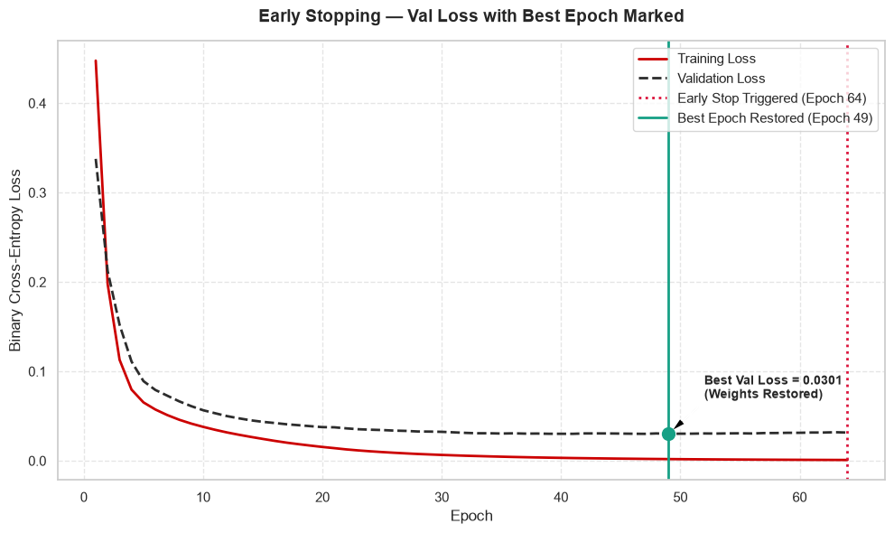

```python
# 4.4: Plot Early Stopping curves
plt.figure(figsize=(10, 6))

epochs_run = len(history_es.history["loss"])
epochs_range = range(1, epochs_run + 1)

# Training and validation loss
plt.plot(
    epochs_range,
    history_es.history["loss"],
    color="#CC0000",
    label="Training Loss",
    linewidth=2,
)
plt.plot(
    epochs_range,
    history_es.history["val_loss"],
    color="#2C2C2C",
    linestyle="--",
    label="Validation Loss",
    linewidth=2,
)

# Mark the best epoch (where weights were restored)
best_epoch = int(np.argmin(history_es.history["val_loss"])) + 1
best_val_loss = min(history_es.history["val_loss"])

# Vertical dashed line at stopping epoch
plt.axvline(
    x=epochs_run,
    color="crimson",
    linestyle=":",
    linewidth=2,
    label=f"Early Stop Triggered (Epoch {epochs_run})",
)
plt.axvline(
    x=best_epoch,
    color="#16a085",
    linestyle="-",
    linewidth=2,
    label=f"Best Epoch Restored (Epoch {best_epoch})",
)

plt.scatter([best_epoch], [best_val_loss], color="#16a085", s=100, zorder=5)
plt.annotate(
    f"Best Val Loss = {best_val_loss:.4f}\n(Weights Restored)",
    xy=(best_epoch, best_val_loss),
    xytext=(best_epoch + 3, best_val_loss + 0.04),
    arrowprops=dict(facecolor="black", shrink=0.08, width=1, headwidth=6),
    fontweight="bold",
    fontsize=10,
)

plt.title(
    "Early Stopping — Val Loss with Best Epoch Marked",
    fontsize=14,
    fontweight="bold",
    pad=15,
)
plt.xlabel("Epoch", fontsize=12)
plt.ylabel("Binary Cross-Entropy Loss", fontsize=12)
plt.legend(loc="upper right")
plt.grid(True, linestyle="--", alpha=0.5)
plt.tight_layout()
plt.show()
```

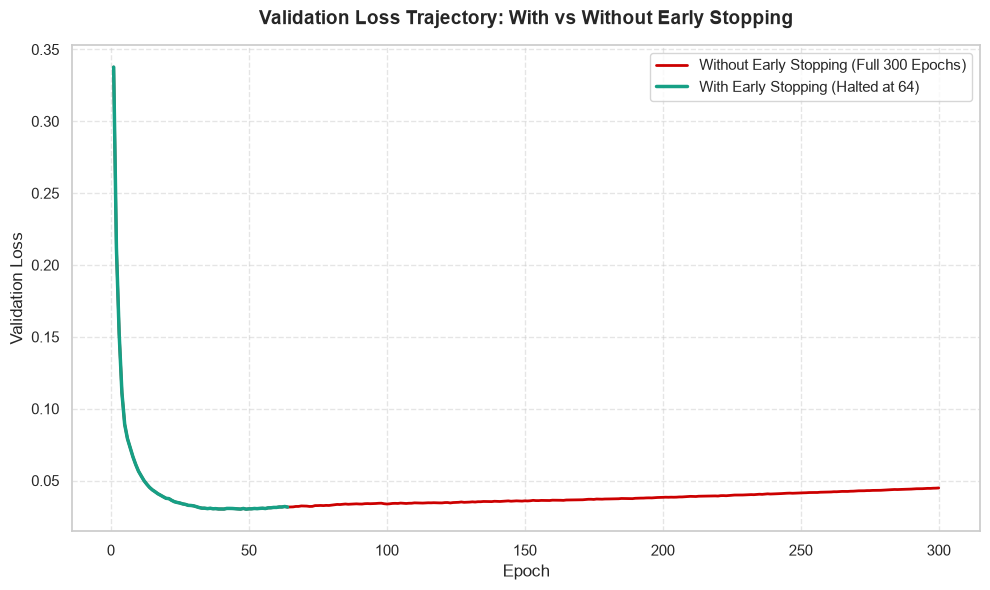

```
=================================================================
MLP with Early Stopping:    Test Loss: 0.1272 | Test Acc: 96.49% (Trained 64 epochs)
MLP without Early Stopping: Test Loss: 0.2486 | Test Acc: 97.37% (Trained 300 epochs)
=================================================================
```

```python
# 4.5: Compare: with vs without Early Stopping
tf.keras.utils.set_random_seed(42)

model_no_es = keras.Sequential(
    [
        keras.layers.Dense(128, activation="relu", input_shape=(30,)),
        keras.layers.Dense(64, activation="relu"),
        keras.layers.Dense(1, activation="sigmoid"),
    ]
)
model_no_es.compile(optimizer="adam", loss="binary_crossentropy", metrics=["accuracy"])

# Train without callbacks for full 300 epochs
history_no_es = model_no_es.fit(
    X_train_sc, y_train, epochs=300, batch_size=32, validation_split=0.1, verbose=0
)

# Plot validation loss comparison
plt.figure(figsize=(10, 6))
plt.plot(
    range(1, 301),
    history_no_es.history["val_loss"],
    color="#CC0000",
    label="Without Early Stopping (Full 300 Epochs)",
    linewidth=2,
)
plt.plot(
    epochs_range,
    history_es.history["val_loss"],
    color="#16a085",
    linewidth=2.5,
    label=f"With Early Stopping (Halted at {epochs_run})",
)

plt.title(
    "Validation Loss Trajectory: With vs Without Early Stopping",
    fontsize=14,
    fontweight="bold",
    pad=15,
)
plt.xlabel("Epoch", fontsize=12)
plt.ylabel("Validation Loss", fontsize=12)
plt.legend(fontsize=11)
plt.grid(True, linestyle="--", alpha=0.5)
plt.tight_layout()
plt.show()

# Evaluate both on test set
loss_es, acc_es = model_es.evaluate(X_test_sc, y_test, verbose=0)
loss_no_es, acc_no_es = model_no_es.evaluate(X_test_sc, y_test, verbose=0)

print("=" * 65)
print(
    f"MLP with Early Stopping:    Test Loss: {loss_es:.4f} | Test Acc: {acc_es*100:.2f}% (Trained {epochs_run} epochs)"
)
print(
    f"MLP without Early Stopping: Test Loss: {loss_no_es:.4f} | Test Acc: {acc_no_es*100:.2f}% (Trained 300 epochs)"
)
print("=" * 65)

results_comparison["MLP with Early Stopping"] = {
    "Test Accuracy": acc_es,
    "Test Loss": loss_es,
    "Trainable Params": model_es.count_params(),
}
results_comparison["MLP without Early Stopping (300 Epochs)"] = {
    "Test Accuracy": acc_no_es,
    "Test Loss": loss_no_es,
    "Trainable Params": model_no_es.count_params(),
}
```

### **Task 5: Dropout Layers**

[output not shown]

```python
# 5.1: Build MLP with Dropout
tf.keras.utils.set_random_seed(42)

model_drop = keras.Sequential(
    [
        keras.layers.Dense(128, activation="relu", input_shape=(30,)),
        keras.layers.Dropout(0.3),
        keras.layers.Dense(64, activation="relu"),
        keras.layers.Dropout(0.3),
        keras.layers.Dense(1, activation="sigmoid"),
    ]
)

print("=" * 65)
print("MLP with Dropout (rate = 0.3) Summary:")
print("=" * 65)
model_drop.summary()

# Confirm that Dropout has 0 trainable parameters
print(f"\nTotal Model Parameters:     {model_drop.count_params()}")
print("Note: Dropout layers introduce exactly 0 parameters.")
```

```
=================================================================
MLP with Dropout (rate = 0.3) Summary:
=================================================================
```

```
Model: "sequential_6"
```

```
┏━━━━━━━━━━━━━━━━━━━━━━━━━━━━━━━━━┳━━━━━━━━━━━━━━━━━━━━━━━━┳━━━━━━━━━━━━━━━┓
┃ Layer (type)                    ┃ Output Shape           ┃       Param # ┃
┡━━━━━━━━━━━━━━━━━━━━━━━━━━━━━━━━━╇━━━━━━━━━━━━━━━━━━━━━━━━╇━━━━━━━━━━━━━━━┩
│ dense_16 (Dense)                │ (None, 128)            │         3,968 │
├─────────────────────────────────┼────────────────────────┼───────────────┤
│ dropout (Dropout)               │ (None, 128)            │             0 │
├─────────────────────────────────┼────────────────────────┼───────────────┤
│ dense_17 (Dense)                │ (None, 64)             │         8,256 │
├─────────────────────────────────┼────────────────────────┼───────────────┤
│ dropout_1 (Dropout)             │ (None, 64)             │             0 │
├─────────────────────────────────┼────────────────────────┼───────────────┤
│ dense_18 (Dense)                │ (None, 1)              │            65 │
└─────────────────────────────────┴────────────────────────┴───────────────┘
```

```
 Total params: 12,289 (48.00 KB)
```

```
 Trainable params: 12,289 (48.00 KB)
```

```
 Non-trainable params: 0 (0.00 B)
```

```
Total Model Parameters:     12289
Note: Dropout layers introduce exactly 0 parameters.
```

#### **Mathematical & Ensemble Intuition of Dropout**

- **Zero Trainable Parameters:** Dropout introduces zero trainable weights ($0$ parameters). It functions strictly as a stochastic regularization mask during backpropagation.
- **Breaking Feature Co-Adaptation:** By randomly zeroing out 30% of neuron activations (`rate=0.3`) per mini-batch, no single neuron can rely on the presence of another. This forces the network to learn robust, distributed representations across features.
- **Implicit Ensemble of $2^n$ Subnetworks:** Dropout approximates training an ensemble of $2^n$ thinned subnetworks with shared weights. At test time (`model.predict()`), Dropout is automatically deactivated and activations are scaled by $(1 - p)$, computing an efficient geometric mean ensemble prediction.

```python
# 5.3: Train with Dropout + Early Stopping
model_drop.compile(optimizer="adam", loss="binary_crossentropy", metrics=["accuracy"])

es_drop = EarlyStopping(
    monitor="val_loss", patience=20, restore_best_weights=True, verbose=1
)

history_drop = model_drop.fit(
    X_train_sc,
    y_train,
    epochs=300,
    batch_size=32,
    validation_split=0.1,
    callbacks=[es_drop],
    verbose=1,
)
```

```
 1/13 ━━━━━━━━━━━━━━━━━━━━ 5s 462ms/step - accuracy: 0.4375 - loss: 0.7879
```

```
13/13 ━━━━━━━━━━━━━━━━━━━━ 1s 9ms/step - accuracy: 0.7800 - loss: 0.5013 - val_accuracy: 0.8913 - val_loss: 0.3399
```

```
 1/13 ━━━━━━━━━━━━━━━━━━━━ 0s 14ms/step - accuracy: 0.9375 - loss: 0.3072
```

```
13/13 ━━━━━━━━━━━━━━━━━━━━ 0s 4ms/step - accuracy: 0.9487 - loss: 0.2294 - val_accuracy: 0.9130 - val_loss: 0.2325
```

```
 1/13 ━━━━━━━━━━━━━━━━━━━━ 0s 14ms/step - accuracy: 0.9375 - loss: 0.1498
```

```
13/13 ━━━━━━━━━━━━━━━━━━━━ 0s 4ms/step - accuracy: 0.9438 - loss: 0.1541 - val_accuracy: 0.9130 - val_loss: 0.1876
```

```
 1/13 ━━━━━━━━━━━━━━━━━━━━ 0s 14ms/step - accuracy: 0.9688 - loss: 0.1006
```

```
13/13 ━━━━━━━━━━━━━━━━━━━━ 0s 4ms/step - accuracy: 0.9658 - loss: 0.1158 - val_accuracy: 0.9565 - val_loss: 0.1488
```

```
 1/13 ━━━━━━━━━━━━━━━━━━━━ 0s 15ms/step - accuracy: 1.0000 - loss: 0.0853
```

```
13/13 ━━━━━━━━━━━━━━━━━━━━ 0s 4ms/step - accuracy: 0.9731 - loss: 0.0965 - val_accuracy: 0.9565 - val_loss: 0.1128
```

```
 1/13 ━━━━━━━━━━━━━━━━━━━━ 0s 14ms/step - accuracy: 0.9688 - loss: 0.0877
```

```
13/13 ━━━━━━━━━━━━━━━━━━━━ 0s 4ms/step - accuracy: 0.9804 - loss: 0.0739 - val_accuracy: 0.9565 - val_loss: 0.0924
```

```
 1/13 ━━━━━━━━━━━━━━━━━━━━ 0s 18ms/step - accuracy: 1.0000 - loss: 0.0582
```

```
13/13 ━━━━━━━━━━━━━━━━━━━━ 0s 4ms/step - accuracy: 0.9804 - loss: 0.0712 - val_accuracy: 0.9783 - val_loss: 0.0773
```

```
 1/13 ━━━━━━━━━━━━━━━━━━━━ 0s 14ms/step - accuracy: 0.9688 - loss: 0.0489
```

```
13/13 ━━━━━━━━━━━━━━━━━━━━ 0s 4ms/step - accuracy: 0.9804 - loss: 0.0612 - val_accuracy: 0.9783 - val_loss: 0.0746
```

```
 1/13 ━━━━━━━━━━━━━━━━━━━━ 0s 14ms/step - accuracy: 1.0000 - loss: 0.0283
```

```
13/13 ━━━━━━━━━━━━━━━━━━━━ 0s 4ms/step - accuracy: 0.9853 - loss: 0.0600 - val_accuracy: 0.9783 - val_loss: 0.0734
```

```
 1/13 ━━━━━━━━━━━━━━━━━━━━ 0s 15ms/step - accuracy: 1.0000 - loss: 0.0456
```

```
13/13 ━━━━━━━━━━━━━━━━━━━━ 0s 3ms/step - accuracy: 0.9853 - loss: 0.0565 - val_accuracy: 0.9783 - val_loss: 0.0658
```

```
 1/13 ━━━━━━━━━━━━━━━━━━━━ 0s 14ms/step - accuracy: 1.0000 - loss: 0.0291
```

```
13/13 ━━━━━━━━━━━━━━━━━━━━ 0s 4ms/step - accuracy: 0.9853 - loss: 0.0454 - val_accuracy: 0.9783 - val_loss: 0.0651
```

```
 1/13 ━━━━━━━━━━━━━━━━━━━━ 0s 15ms/step - accuracy: 1.0000 - loss: 0.0200
```

```
13/13 ━━━━━━━━━━━━━━━━━━━━ 0s 4ms/step - accuracy: 0.9902 - loss: 0.0469 - val_accuracy: 0.9783 - val_loss: 0.0669
```

```
 1/13 ━━━━━━━━━━━━━━━━━━━━ 0s 14ms/step - accuracy: 1.0000 - loss: 0.0177
```

```
13/13 ━━━━━━━━━━━━━━━━━━━━ 0s 3ms/step - accuracy: 0.9878 - loss: 0.0410 - val_accuracy: 0.9783 - val_loss: 0.0640
```

```
 1/13 ━━━━━━━━━━━━━━━━━━━━ 0s 14ms/step - accuracy: 1.0000 - loss: 0.0274
```

```
13/13 ━━━━━━━━━━━━━━━━━━━━ 0s 3ms/step - accuracy: 0.9902 - loss: 0.0364 - val_accuracy: 0.9783 - val_loss: 0.0585
```

```
 1/13 ━━━━━━━━━━━━━━━━━━━━ 0s 13ms/step - accuracy: 1.0000 - loss: 0.0364
```

```
13/13 ━━━━━━━━━━━━━━━━━━━━ 0s 4ms/step - accuracy: 0.9927 - loss: 0.0389 - val_accuracy: 0.9783 - val_loss: 0.0548
```

```
 1/13 ━━━━━━━━━━━━━━━━━━━━ 0s 14ms/step - accuracy: 1.0000 - loss: 0.0151
```

```
13/13 ━━━━━━━━━━━━━━━━━━━━ 0s 3ms/step - accuracy: 0.9927 - loss: 0.0346 - val_accuracy: 0.9783 - val_loss: 0.0484
```

```
 1/13 ━━━━━━━━━━━━━━━━━━━━ 0s 15ms/step - accuracy: 0.9688 - loss: 0.0428
```

```
13/13 ━━━━━━━━━━━━━━━━━━━━ 0s 3ms/step - accuracy: 0.9878 - loss: 0.0362 - val_accuracy: 0.9783 - val_loss: 0.0452
```

```
 1/13 ━━━━━━━━━━━━━━━━━━━━ 0s 14ms/step - accuracy: 1.0000 - loss: 0.0146
```

```
13/13 ━━━━━━━━━━━━━━━━━━━━ 0s 3ms/step - accuracy: 0.9878 - loss: 0.0279 - val_accuracy: 0.9783 - val_loss: 0.0442
```

```
 1/13 ━━━━━━━━━━━━━━━━━━━━ 0s 14ms/step - accuracy: 0.9688 - loss: 0.0363
```

```
13/13 ━━━━━━━━━━━━━━━━━━━━ 0s 3ms/step - accuracy: 0.9902 - loss: 0.0280 - val_accuracy: 0.9783 - val_loss: 0.0391
```

```
 1/13 ━━━━━━━━━━━━━━━━━━━━ 0s 14ms/step - accuracy: 0.9688 - loss: 0.0711
```

```
13/13 ━━━━━━━━━━━━━━━━━━━━ 0s 3ms/step - accuracy: 0.9902 - loss: 0.0297 - val_accuracy: 0.9783 - val_loss: 0.0403
```

```
 1/13 ━━━━━━━━━━━━━━━━━━━━ 0s 14ms/step - accuracy: 1.0000 - loss: 0.0120
```

```
13/13 ━━━━━━━━━━━━━━━━━━━━ 0s 3ms/step - accuracy: 0.9902 - loss: 0.0312 - val_accuracy: 1.0000 - val_loss: 0.0315
```

```
 1/13 ━━━━━━━━━━━━━━━━━━━━ 0s 14ms/step - accuracy: 0.9688 - loss: 0.0240
```

```
13/13 ━━━━━━━━━━━━━━━━━━━━ 0s 4ms/step - accuracy: 0.9902 - loss: 0.0284 - val_accuracy: 1.0000 - val_loss: 0.0306
```

```
 1/13 ━━━━━━━━━━━━━━━━━━━━ 0s 14ms/step - accuracy: 1.0000 - loss: 0.0107
```

```
13/13 ━━━━━━━━━━━━━━━━━━━━ 0s 3ms/step - accuracy: 0.9951 - loss: 0.0236 - val_accuracy: 0.9783 - val_loss: 0.0343
```

```
 1/13 ━━━━━━━━━━━━━━━━━━━━ 0s 15ms/step - accuracy: 1.0000 - loss: 0.0119
```

```
13/13 ━━━━━━━━━━━━━━━━━━━━ 0s 3ms/step - accuracy: 0.9902 - loss: 0.0247 - val_accuracy: 0.9783 - val_loss: 0.0364
```

```
 1/13 ━━━━━━━━━━━━━━━━━━━━ 0s 14ms/step - accuracy: 1.0000 - loss: 0.0068
```

```
13/13 ━━━━━━━━━━━━━━━━━━━━ 0s 3ms/step - accuracy: 0.9902 - loss: 0.0218 - val_accuracy: 0.9783 - val_loss: 0.0360
```

```
 1/13 ━━━━━━━━━━━━━━━━━━━━ 0s 13ms/step - accuracy: 1.0000 - loss: 0.0143
```

```
13/13 ━━━━━━━━━━━━━━━━━━━━ 0s 3ms/step - accuracy: 0.9927 - loss: 0.0212 - val_accuracy: 0.9783 - val_loss: 0.0371
```

```
 1/13 ━━━━━━━━━━━━━━━━━━━━ 0s 14ms/step - accuracy: 1.0000 - loss: 0.0026
```

```
13/13 ━━━━━━━━━━━━━━━━━━━━ 0s 4ms/step - accuracy: 0.9927 - loss: 0.0210 - val_accuracy: 0.9783 - val_loss: 0.0303
```

```
 1/13 ━━━━━━━━━━━━━━━━━━━━ 0s 14ms/step - accuracy: 1.0000 - loss: 0.0158
```

```
13/13 ━━━━━━━━━━━━━━━━━━━━ 0s 3ms/step - accuracy: 0.9902 - loss: 0.0231 - val_accuracy: 0.9783 - val_loss: 0.0384
```

```
 1/13 ━━━━━━━━━━━━━━━━━━━━ 0s 14ms/step - accuracy: 1.0000 - loss: 0.0096
```

```
13/13 ━━━━━━━━━━━━━━━━━━━━ 0s 3ms/step - accuracy: 0.9878 - loss: 0.0212 - val_accuracy: 0.9783 - val_loss: 0.0384
```

```
 1/13 ━━━━━━━━━━━━━━━━━━━━ 0s 15ms/step - accuracy: 1.0000 - loss: 0.0057
```

```
13/13 ━━━━━━━━━━━━━━━━━━━━ 0s 3ms/step - accuracy: 0.9976 - loss: 0.0181 - val_accuracy: 0.9783 - val_loss: 0.0331
```

```
 1/13 ━━━━━━━━━━━━━━━━━━━━ 0s 14ms/step - accuracy: 1.0000 - loss: 0.0120
```

```
13/13 ━━━━━━━━━━━━━━━━━━━━ 0s 4ms/step - accuracy: 0.9951 - loss: 0.0161 - val_accuracy: 0.9783 - val_loss: 0.0266
```

```
 1/13 ━━━━━━━━━━━━━━━━━━━━ 0s 17ms/step - accuracy: 1.0000 - loss: 0.0245
```

```
13/13 ━━━━━━━━━━━━━━━━━━━━ 0s 4ms/step - accuracy: 0.9951 - loss: 0.0180 - val_accuracy: 0.9783 - val_loss: 0.0318
```

```
 1/13 ━━━━━━━━━━━━━━━━━━━━ 0s 15ms/step - accuracy: 1.0000 - loss: 0.0027
```

```
13/13 ━━━━━━━━━━━━━━━━━━━━ 0s 4ms/step - accuracy: 0.9927 - loss: 0.0172 - val_accuracy: 0.9783 - val_loss: 0.0289
```

```
 1/13 ━━━━━━━━━━━━━━━━━━━━ 0s 14ms/step - accuracy: 1.0000 - loss: 0.0042
```

```
13/13 ━━━━━━━━━━━━━━━━━━━━ 0s 3ms/step - accuracy: 0.9927 - loss: 0.0190 - val_accuracy: 1.0000 - val_loss: 0.0251
```

```
 1/13 ━━━━━━━━━━━━━━━━━━━━ 0s 16ms/step - accuracy: 1.0000 - loss: 0.0094
```

```
13/13 ━━━━━━━━━━━━━━━━━━━━ 0s 4ms/step - accuracy: 1.0000 - loss: 0.0094 - val_accuracy: 0.9783 - val_loss: 0.0268
```

```
 1/13 ━━━━━━━━━━━━━━━━━━━━ 0s 13ms/step - accuracy: 1.0000 - loss: 0.0073
```

```
13/13 ━━━━━━━━━━━━━━━━━━━━ 0s 4ms/step - accuracy: 0.9927 - loss: 0.0176 - val_accuracy: 0.9783 - val_loss: 0.0246
```

```
 1/13 ━━━━━━━━━━━━━━━━━━━━ 0s 13ms/step - accuracy: 1.0000 - loss: 0.0062
```

```
13/13 ━━━━━━━━━━━━━━━━━━━━ 0s 3ms/step - accuracy: 0.9927 - loss: 0.0166 - val_accuracy: 1.0000 - val_loss: 0.0213
```

```
 1/13 ━━━━━━━━━━━━━━━━━━━━ 0s 14ms/step - accuracy: 1.0000 - loss: 0.0040
```

```
13/13 ━━━━━━━━━━━━━━━━━━━━ 0s 4ms/step - accuracy: 0.9951 - loss: 0.0119 - val_accuracy: 1.0000 - val_loss: 0.0221
```

```
 1/13 ━━━━━━━━━━━━━━━━━━━━ 0s 14ms/step - accuracy: 1.0000 - loss: 0.0151
```

```
13/13 ━━━━━━━━━━━━━━━━━━━━ 0s 3ms/step - accuracy: 0.9976 - loss: 0.0126 - val_accuracy: 0.9783 - val_loss: 0.0322
```

```
 1/13 ━━━━━━━━━━━━━━━━━━━━ 0s 14ms/step - accuracy: 1.0000 - loss: 0.0028
```

```
13/13 ━━━━━━━━━━━━━━━━━━━━ 0s 3ms/step - accuracy: 0.9976 - loss: 0.0084 - val_accuracy: 0.9783 - val_loss: 0.0310
```

```
 1/13 ━━━━━━━━━━━━━━━━━━━━ 0s 14ms/step - accuracy: 1.0000 - loss: 0.0021
```

```
13/13 ━━━━━━━━━━━━━━━━━━━━ 0s 4ms/step - accuracy: 0.9976 - loss: 0.0087 - val_accuracy: 1.0000 - val_loss: 0.0209
```

```
 1/13 ━━━━━━━━━━━━━━━━━━━━ 0s 14ms/step - accuracy: 1.0000 - loss: 0.0022
```

```
13/13 ━━━━━━━━━━━━━━━━━━━━ 0s 4ms/step - accuracy: 0.9951 - loss: 0.0129 - val_accuracy: 1.0000 - val_loss: 0.0187
```

```
 1/13 ━━━━━━━━━━━━━━━━━━━━ 0s 14ms/step - accuracy: 1.0000 - loss: 0.0069
```

```
13/13 ━━━━━━━━━━━━━━━━━━━━ 0s 4ms/step - accuracy: 0.9951 - loss: 0.0116 - val_accuracy: 1.0000 - val_loss: 0.0128
```

```
 1/13 ━━━━━━━━━━━━━━━━━━━━ 0s 14ms/step - accuracy: 1.0000 - loss: 0.0059
```

```
13/13 ━━━━━━━━━━━━━━━━━━━━ 0s 3ms/step - accuracy: 0.9976 - loss: 0.0111 - val_accuracy: 1.0000 - val_loss: 0.0136
```

```
 1/13 ━━━━━━━━━━━━━━━━━━━━ 0s 16ms/step - accuracy: 1.0000 - loss: 0.0013
```

```
13/13 ━━━━━━━━━━━━━━━━━━━━ 0s 3ms/step - accuracy: 0.9976 - loss: 0.0112 - val_accuracy: 1.0000 - val_loss: 0.0161
```

```
 1/13 ━━━━━━━━━━━━━━━━━━━━ 0s 14ms/step - accuracy: 1.0000 - loss: 0.0015
```

```
13/13 ━━━━━━━━━━━━━━━━━━━━ 0s 3ms/step - accuracy: 1.0000 - loss: 0.0056 - val_accuracy: 1.0000 - val_loss: 0.0150
```

```
 1/13 ━━━━━━━━━━━━━━━━━━━━ 0s 14ms/step - accuracy: 1.0000 - loss: 0.0188
```

```
13/13 ━━━━━━━━━━━━━━━━━━━━ 0s 3ms/step - accuracy: 0.9976 - loss: 0.0143 - val_accuracy: 0.9783 - val_loss: 0.0269
```

```
 1/13 ━━━━━━━━━━━━━━━━━━━━ 0s 14ms/step - accuracy: 1.0000 - loss: 7.4463e-04
```

```
13/13 ━━━━━━━━━━━━━━━━━━━━ 0s 3ms/step - accuracy: 0.9976 - loss: 0.0121 - val_accuracy: 1.0000 - val_loss: 0.0255
```

```
 1/13 ━━━━━━━━━━━━━━━━━━━━ 0s 15ms/step - accuracy: 1.0000 - loss: 0.0070
```

```
13/13 ━━━━━━━━━━━━━━━━━━━━ 0s 3ms/step - accuracy: 0.9976 - loss: 0.0086 - val_accuracy: 1.0000 - val_loss: 0.0116
```

```
 1/13 ━━━━━━━━━━━━━━━━━━━━ 0s 14ms/step - accuracy: 1.0000 - loss: 0.0111
```

```
13/13 ━━━━━━━━━━━━━━━━━━━━ 0s 3ms/step - accuracy: 0.9951 - loss: 0.0116 - val_accuracy: 1.0000 - val_loss: 0.0130
```

```
 1/13 ━━━━━━━━━━━━━━━━━━━━ 0s 14ms/step - accuracy: 1.0000 - loss: 9.0718e-04
```

```
13/13 ━━━━━━━━━━━━━━━━━━━━ 0s 4ms/step - accuracy: 0.9976 - loss: 0.0091 - val_accuracy: 1.0000 - val_loss: 0.0149
```

```
 1/13 ━━━━━━━━━━━━━━━━━━━━ 0s 15ms/step - accuracy: 1.0000 - loss: 7.3613e-04
```

```
13/13 ━━━━━━━━━━━━━━━━━━━━ 0s 3ms/step - accuracy: 0.9951 - loss: 0.0226 - val_accuracy: 1.0000 - val_loss: 0.0145
```

```
 1/13 ━━━━━━━━━━━━━━━━━━━━ 0s 14ms/step - accuracy: 1.0000 - loss: 5.6203e-04
```

```
13/13 ━━━━━━━━━━━━━━━━━━━━ 0s 4ms/step - accuracy: 0.9976 - loss: 0.0070 - val_accuracy: 1.0000 - val_loss: 0.0177
```

```
 1/13 ━━━━━━━━━━━━━━━━━━━━ 0s 14ms/step - accuracy: 1.0000 - loss: 0.0027
```

```
13/13 ━━━━━━━━━━━━━━━━━━━━ 0s 3ms/step - accuracy: 0.9951 - loss: 0.0111 - val_accuracy: 1.0000 - val_loss: 0.0183
```

```
 1/13 ━━━━━━━━━━━━━━━━━━━━ 0s 14ms/step - accuracy: 1.0000 - loss: 0.0043
```

```
13/13 ━━━━━━━━━━━━━━━━━━━━ 0s 4ms/step - accuracy: 1.0000 - loss: 0.0066 - val_accuracy: 1.0000 - val_loss: 0.0219
```

```
 1/13 ━━━━━━━━━━━━━━━━━━━━ 0s 14ms/step - accuracy: 1.0000 - loss: 8.2668e-04
```

```
13/13 ━━━━━━━━━━━━━━━━━━━━ 0s 4ms/step - accuracy: 1.0000 - loss: 0.0080 - val_accuracy: 1.0000 - val_loss: 0.0246
```

```
 1/13 ━━━━━━━━━━━━━━━━━━━━ 0s 16ms/step - accuracy: 1.0000 - loss: 3.5213e-04
```

```
13/13 ━━━━━━━━━━━━━━━━━━━━ 0s 4ms/step - accuracy: 0.9951 - loss: 0.0123 - val_accuracy: 1.0000 - val_loss: 0.0205
```

```
 1/13 ━━━━━━━━━━━━━━━━━━━━ 0s 15ms/step - accuracy: 1.0000 - loss: 0.0102
```

```
13/13 ━━━━━━━━━━━━━━━━━━━━ 0s 4ms/step - accuracy: 1.0000 - loss: 0.0071 - val_accuracy: 1.0000 - val_loss: 0.0216
```

```
 1/13 ━━━━━━━━━━━━━━━━━━━━ 0s 15ms/step - accuracy: 1.0000 - loss: 0.0014
```

```
13/13 ━━━━━━━━━━━━━━━━━━━━ 0s 3ms/step - accuracy: 0.9976 - loss: 0.0071 - val_accuracy: 1.0000 - val_loss: 0.0163
```

```
 1/13 ━━━━━━━━━━━━━━━━━━━━ 0s 15ms/step - accuracy: 1.0000 - loss: 0.0014
```

```
13/13 ━━━━━━━━━━━━━━━━━━━━ 0s 4ms/step - accuracy: 1.0000 - loss: 0.0047 - val_accuracy: 1.0000 - val_loss: 0.0195
```

```
 1/13 ━━━━━━━━━━━━━━━━━━━━ 0s 15ms/step - accuracy: 1.0000 - loss: 0.0016
```

```
13/13 ━━━━━━━━━━━━━━━━━━━━ 0s 4ms/step - accuracy: 0.9976 - loss: 0.0053 - val_accuracy: 1.0000 - val_loss: 0.0177
```

```
 1/13 ━━━━━━━━━━━━━━━━━━━━ 0s 15ms/step - accuracy: 1.0000 - loss: 0.0064
```

```
13/13 ━━━━━━━━━━━━━━━━━━━━ 0s 4ms/step - accuracy: 0.9976 - loss: 0.0060 - val_accuracy: 1.0000 - val_loss: 0.0157
```

```
 1/13 ━━━━━━━━━━━━━━━━━━━━ 0s 14ms/step - accuracy: 1.0000 - loss: 0.0024
```

```
13/13 ━━━━━━━━━━━━━━━━━━━━ 0s 3ms/step - accuracy: 1.0000 - loss: 0.0065 - val_accuracy: 1.0000 - val_loss: 0.0148
```

```
 1/13 ━━━━━━━━━━━━━━━━━━━━ 0s 16ms/step - accuracy: 1.0000 - loss: 5.1064e-04
```

```
13/13 ━━━━━━━━━━━━━━━━━━━━ 0s 4ms/step - accuracy: 1.0000 - loss: 0.0066 - val_accuracy: 1.0000 - val_loss: 0.0127
```

```
 1/13 ━━━━━━━━━━━━━━━━━━━━ 0s 14ms/step - accuracy: 1.0000 - loss: 9.5125e-04
```

```
13/13 ━━━━━━━━━━━━━━━━━━━━ 0s 3ms/step - accuracy: 0.9976 - loss: 0.0069 - val_accuracy: 1.0000 - val_loss: 0.0139
```

```
 1/13 ━━━━━━━━━━━━━━━━━━━━ 0s 13ms/step - accuracy: 1.0000 - loss: 3.9226e-04
```

```
13/13 ━━━━━━━━━━━━━━━━━━━━ 0s 3ms/step - accuracy: 1.0000 - loss: 0.0036 - val_accuracy: 1.0000 - val_loss: 0.0108
```

```
 1/13 ━━━━━━━━━━━━━━━━━━━━ 0s 14ms/step - accuracy: 1.0000 - loss: 0.0056
```

```
13/13 ━━━━━━━━━━━━━━━━━━━━ 0s 3ms/step - accuracy: 0.9976 - loss: 0.0051 - val_accuracy: 1.0000 - val_loss: 0.0097
```

```
 1/13 ━━━━━━━━━━━━━━━━━━━━ 0s 14ms/step - accuracy: 1.0000 - loss: 1.6324e-04
```

```
13/13 ━━━━━━━━━━━━━━━━━━━━ 0s 3ms/step - accuracy: 0.9976 - loss: 0.0068 - val_accuracy: 1.0000 - val_loss: 0.0099
```

```
 1/13 ━━━━━━━━━━━━━━━━━━━━ 0s 13ms/step - accuracy: 1.0000 - loss: 4.2160e-04
```

```
13/13 ━━━━━━━━━━━━━━━━━━━━ 0s 4ms/step - accuracy: 0.9976 - loss: 0.0049 - val_accuracy: 1.0000 - val_loss: 0.0132
```

```
 1/13 ━━━━━━━━━━━━━━━━━━━━ 0s 15ms/step - accuracy: 1.0000 - loss: 0.0031
```

```
13/13 ━━━━━━━━━━━━━━━━━━━━ 0s 4ms/step - accuracy: 0.9951 - loss: 0.0079 - val_accuracy: 1.0000 - val_loss: 0.0119
```

```
 1/13 ━━━━━━━━━━━━━━━━━━━━ 0s 14ms/step - accuracy: 1.0000 - loss: 0.0198
```

```
13/13 ━━━━━━━━━━━━━━━━━━━━ 0s 4ms/step - accuracy: 1.0000 - loss: 0.0047 - val_accuracy: 1.0000 - val_loss: 0.0111
```

```
 1/13 ━━━━━━━━━━━━━━━━━━━━ 0s 15ms/step - accuracy: 1.0000 - loss: 0.0012
```

```
13/13 ━━━━━━━━━━━━━━━━━━━━ 0s 3ms/step - accuracy: 1.0000 - loss: 0.0033 - val_accuracy: 1.0000 - val_loss: 0.0113
```

```
 1/13 ━━━━━━━━━━━━━━━━━━━━ 0s 14ms/step - accuracy: 1.0000 - loss: 0.0017
```

```
13/13 ━━━━━━━━━━━━━━━━━━━━ 0s 4ms/step - accuracy: 1.0000 - loss: 0.0033 - val_accuracy: 1.0000 - val_loss: 0.0108
```

```
 1/13 ━━━━━━━━━━━━━━━━━━━━ 0s 14ms/step - accuracy: 1.0000 - loss: 8.5908e-05
```

```
13/13 ━━━━━━━━━━━━━━━━━━━━ 0s 4ms/step - accuracy: 1.0000 - loss: 0.0044 - val_accuracy: 1.0000 - val_loss: 0.0095
```

```
 1/13 ━━━━━━━━━━━━━━━━━━━━ 0s 15ms/step - accuracy: 1.0000 - loss: 0.0019
```

```
13/13 ━━━━━━━━━━━━━━━━━━━━ 0s 3ms/step - accuracy: 1.0000 - loss: 0.0030 - val_accuracy: 1.0000 - val_loss: 0.0089
```

```
 1/13 ━━━━━━━━━━━━━━━━━━━━ 0s 14ms/step - accuracy: 1.0000 - loss: 8.2384e-05
```

```
13/13 ━━━━━━━━━━━━━━━━━━━━ 0s 3ms/step - accuracy: 1.0000 - loss: 0.0026 - val_accuracy: 1.0000 - val_loss: 0.0099
```

```
 1/13 ━━━━━━━━━━━━━━━━━━━━ 0s 14ms/step - accuracy: 1.0000 - loss: 0.0022
```

```
13/13 ━━━━━━━━━━━━━━━━━━━━ 0s 4ms/step - accuracy: 0.9976 - loss: 0.0065 - val_accuracy: 1.0000 - val_loss: 0.0104
```

```
 1/13 ━━━━━━━━━━━━━━━━━━━━ 0s 16ms/step - accuracy: 1.0000 - loss: 0.0014
```

```
13/13 ━━━━━━━━━━━━━━━━━━━━ 0s 4ms/step - accuracy: 1.0000 - loss: 0.0018 - val_accuracy: 1.0000 - val_loss: 0.0074
```

```
 1/13 ━━━━━━━━━━━━━━━━━━━━ 0s 15ms/step - accuracy: 1.0000 - loss: 9.1151e-04
```

```
13/13 ━━━━━━━━━━━━━━━━━━━━ 0s 4ms/step - accuracy: 1.0000 - loss: 0.0033 - val_accuracy: 1.0000 - val_loss: 0.0071
```

```
 1/13 ━━━━━━━━━━━━━━━━━━━━ 0s 14ms/step - accuracy: 1.0000 - loss: 2.1003e-04
```

```
13/13 ━━━━━━━━━━━━━━━━━━━━ 0s 3ms/step - accuracy: 0.9976 - loss: 0.0055 - val_accuracy: 1.0000 - val_loss: 0.0140
```

```
 1/13 ━━━━━━━━━━━━━━━━━━━━ 0s 15ms/step - accuracy: 1.0000 - loss: 1.9417e-04
```

```
13/13 ━━━━━━━━━━━━━━━━━━━━ 0s 3ms/step - accuracy: 1.0000 - loss: 0.0051 - val_accuracy: 1.0000 - val_loss: 0.0076
```

```
 1/13 ━━━━━━━━━━━━━━━━━━━━ 0s 15ms/step - accuracy: 1.0000 - loss: 2.9624e-04
```

```
13/13 ━━━━━━━━━━━━━━━━━━━━ 0s 4ms/step - accuracy: 0.9976 - loss: 0.0149 - val_accuracy: 1.0000 - val_loss: 0.0072
```

```
 1/13 ━━━━━━━━━━━━━━━━━━━━ 0s 15ms/step - accuracy: 1.0000 - loss: 1.2104e-05
```

```
13/13 ━━━━━━━━━━━━━━━━━━━━ 0s 4ms/step - accuracy: 0.9976 - loss: 0.0107 - val_accuracy: 1.0000 - val_loss: 0.0058
```

```
 1/13 ━━━━━━━━━━━━━━━━━━━━ 0s 14ms/step - accuracy: 1.0000 - loss: 0.0172
```

```
13/13 ━━━━━━━━━━━━━━━━━━━━ 0s 4ms/step - accuracy: 0.9951 - loss: 0.0083 - val_accuracy: 1.0000 - val_loss: 0.0086
```

```
 1/13 ━━━━━━━━━━━━━━━━━━━━ 0s 15ms/step - accuracy: 1.0000 - loss: 0.0097
```

```
13/13 ━━━━━━━━━━━━━━━━━━━━ 0s 4ms/step - accuracy: 1.0000 - loss: 0.0052 - val_accuracy: 1.0000 - val_loss: 0.0148
```

```
 1/13 ━━━━━━━━━━━━━━━━━━━━ 0s 14ms/step - accuracy: 1.0000 - loss: 0.0048
```

```
13/13 ━━━━━━━━━━━━━━━━━━━━ 0s 4ms/step - accuracy: 1.0000 - loss: 0.0053 - val_accuracy: 1.0000 - val_loss: 0.0165
```

```
 1/13 ━━━━━━━━━━━━━━━━━━━━ 0s 15ms/step - accuracy: 1.0000 - loss: 3.0875e-04
```

```
13/13 ━━━━━━━━━━━━━━━━━━━━ 0s 4ms/step - accuracy: 0.9976 - loss: 0.0086 - val_accuracy: 0.9783 - val_loss: 0.0191
```

```
 1/13 ━━━━━━━━━━━━━━━━━━━━ 0s 15ms/step - accuracy: 1.0000 - loss: 6.5374e-04
```

```
13/13 ━━━━━━━━━━━━━━━━━━━━ 0s 4ms/step - accuracy: 1.0000 - loss: 0.0027 - val_accuracy: 0.9783 - val_loss: 0.0193
```

```
 1/13 ━━━━━━━━━━━━━━━━━━━━ 0s 14ms/step - accuracy: 1.0000 - loss: 4.7604e-05
```

```
13/13 ━━━━━━━━━━━━━━━━━━━━ 0s 4ms/step - accuracy: 1.0000 - loss: 0.0025 - val_accuracy: 1.0000 - val_loss: 0.0168
```

```
 1/13 ━━━━━━━━━━━━━━━━━━━━ 0s 15ms/step - accuracy: 1.0000 - loss: 7.7198e-04
```

```
13/13 ━━━━━━━━━━━━━━━━━━━━ 0s 4ms/step - accuracy: 1.0000 - loss: 0.0033 - val_accuracy: 1.0000 - val_loss: 0.0141
```

```
 1/13 ━━━━━━━━━━━━━━━━━━━━ 0s 15ms/step - accuracy: 1.0000 - loss: 1.2812e-04
```

```
13/13 ━━━━━━━━━━━━━━━━━━━━ 0s 4ms/step - accuracy: 0.9976 - loss: 0.0085 - val_accuracy: 1.0000 - val_loss: 0.0119
```

```
 1/13 ━━━━━━━━━━━━━━━━━━━━ 0s 15ms/step - accuracy: 1.0000 - loss: 2.1300e-04
```

```
13/13 ━━━━━━━━━━━━━━━━━━━━ 0s 4ms/step - accuracy: 1.0000 - loss: 0.0019 - val_accuracy: 1.0000 - val_loss: 0.0103
```

```
 1/13 ━━━━━━━━━━━━━━━━━━━━ 0s 16ms/step - accuracy: 1.0000 - loss: 5.0272e-05
```

```
13/13 ━━━━━━━━━━━━━━━━━━━━ 0s 4ms/step - accuracy: 1.0000 - loss: 0.0026 - val_accuracy: 1.0000 - val_loss: 0.0095
```

```
 1/13 ━━━━━━━━━━━━━━━━━━━━ 0s 15ms/step - accuracy: 1.0000 - loss: 0.0072
```

```
13/13 ━━━━━━━━━━━━━━━━━━━━ 0s 4ms/step - accuracy: 1.0000 - loss: 0.0034 - val_accuracy: 1.0000 - val_loss: 0.0101
```

```
 1/13 ━━━━━━━━━━━━━━━━━━━━ 0s 15ms/step - accuracy: 1.0000 - loss: 3.3823e-04
```

```
13/13 ━━━━━━━━━━━━━━━━━━━━ 0s 4ms/step - accuracy: 1.0000 - loss: 0.0022 - val_accuracy: 1.0000 - val_loss: 0.0104
```

```
 1/13 ━━━━━━━━━━━━━━━━━━━━ 0s 15ms/step - accuracy: 1.0000 - loss: 1.6643e-04
```

```
13/13 ━━━━━━━━━━━━━━━━━━━━ 0s 4ms/step - accuracy: 0.9951 - loss: 0.0058 - val_accuracy: 1.0000 - val_loss: 0.0109
```

```
 1/13 ━━━━━━━━━━━━━━━━━━━━ 0s 15ms/step - accuracy: 1.0000 - loss: 0.0029
```

```
13/13 ━━━━━━━━━━━━━━━━━━━━ 0s 4ms/step - accuracy: 0.9976 - loss: 0.0049 - val_accuracy: 1.0000 - val_loss: 0.0120
```

```
 1/13 ━━━━━━━━━━━━━━━━━━━━ 0s 15ms/step - accuracy: 1.0000 - loss: 9.8988e-05
```

```
13/13 ━━━━━━━━━━━━━━━━━━━━ 0s 4ms/step - accuracy: 1.0000 - loss: 0.0049 - val_accuracy: 1.0000 - val_loss: 0.0087
```

```
 1/13 ━━━━━━━━━━━━━━━━━━━━ 0s 15ms/step - accuracy: 1.0000 - loss: 2.3364e-04
```

```
13/13 ━━━━━━━━━━━━━━━━━━━━ 0s 4ms/step - accuracy: 1.0000 - loss: 0.0032 - val_accuracy: 1.0000 - val_loss: 0.0088
```

```
 1/13 ━━━━━━━━━━━━━━━━━━━━ 0s 14ms/step - accuracy: 1.0000 - loss: 8.5746e-05
```

```
13/13 ━━━━━━━━━━━━━━━━━━━━ 0s 4ms/step - accuracy: 1.0000 - loss: 0.0053 - val_accuracy: 1.0000 - val_loss: 0.0057
```

```
 1/13 ━━━━━━━━━━━━━━━━━━━━ 0s 14ms/step - accuracy: 1.0000 - loss: 2.4564e-04
```

```
13/13 ━━━━━━━━━━━━━━━━━━━━ 0s 4ms/step - accuracy: 1.0000 - loss: 0.0028 - val_accuracy: 1.0000 - val_loss: 0.0051
```

```
 1/13 ━━━━━━━━━━━━━━━━━━━━ 0s 16ms/step - accuracy: 1.0000 - loss: 0.0016
```

```
13/13 ━━━━━━━━━━━━━━━━━━━━ 0s 3ms/step - accuracy: 1.0000 - loss: 0.0024 - val_accuracy: 1.0000 - val_loss: 0.0047
```

```
 1/13 ━━━━━━━━━━━━━━━━━━━━ 0s 14ms/step - accuracy: 1.0000 - loss: 0.0018
```

```
13/13 ━━━━━━━━━━━━━━━━━━━━ 0s 3ms/step - accuracy: 1.0000 - loss: 0.0019 - val_accuracy: 1.0000 - val_loss: 0.0055
```

```
 1/13 ━━━━━━━━━━━━━━━━━━━━ 0s 15ms/step - accuracy: 1.0000 - loss: 1.1710e-04
```

```
13/13 ━━━━━━━━━━━━━━━━━━━━ 0s 4ms/step - accuracy: 1.0000 - loss: 0.0018 - val_accuracy: 1.0000 - val_loss: 0.0059
```

```
 1/13 ━━━━━━━━━━━━━━━━━━━━ 0s 15ms/step - accuracy: 1.0000 - loss: 3.9636e-05
```

```
13/13 ━━━━━━━━━━━━━━━━━━━━ 0s 4ms/step - accuracy: 1.0000 - loss: 0.0021 - val_accuracy: 1.0000 - val_loss: 0.0053
```

```
 1/13 ━━━━━━━━━━━━━━━━━━━━ 0s 14ms/step - accuracy: 1.0000 - loss: 0.0017
```

```
13/13 ━━━━━━━━━━━━━━━━━━━━ 0s 4ms/step - accuracy: 1.0000 - loss: 0.0018 - val_accuracy: 1.0000 - val_loss: 0.0083
```

```
 1/13 ━━━━━━━━━━━━━━━━━━━━ 0s 21ms/step - accuracy: 1.0000 - loss: 9.7694e-05
```

```
13/13 ━━━━━━━━━━━━━━━━━━━━ 0s 4ms/step - accuracy: 1.0000 - loss: 0.0019 - val_accuracy: 1.0000 - val_loss: 0.0078
```

```
 1/13 ━━━━━━━━━━━━━━━━━━━━ 0s 15ms/step - accuracy: 1.0000 - loss: 0.0012
```

```
13/13 ━━━━━━━━━━━━━━━━━━━━ 0s 4ms/step - accuracy: 1.0000 - loss: 0.0027 - val_accuracy: 1.0000 - val_loss: 0.0062
```

```
 1/13 ━━━━━━━━━━━━━━━━━━━━ 0s 14ms/step - accuracy: 1.0000 - loss: 2.1048e-05
```

```
13/13 ━━━━━━━━━━━━━━━━━━━━ 0s 4ms/step - accuracy: 1.0000 - loss: 0.0029 - val_accuracy: 1.0000 - val_loss: 0.0063
```

```
 1/13 ━━━━━━━━━━━━━━━━━━━━ 0s 16ms/step - accuracy: 1.0000 - loss: 1.2162e-04
```

```
13/13 ━━━━━━━━━━━━━━━━━━━━ 0s 4ms/step - accuracy: 1.0000 - loss: 0.0015 - val_accuracy: 1.0000 - val_loss: 0.0063
```

```
 1/13 ━━━━━━━━━━━━━━━━━━━━ 0s 14ms/step - accuracy: 1.0000 - loss: 1.5089e-04
```

```
13/13 ━━━━━━━━━━━━━━━━━━━━ 0s 4ms/step - accuracy: 1.0000 - loss: 0.0016 - val_accuracy: 1.0000 - val_loss: 0.0066
```

```
 1/13 ━━━━━━━━━━━━━━━━━━━━ 0s 14ms/step - accuracy: 1.0000 - loss: 9.1434e-04
```

```
13/13 ━━━━━━━━━━━━━━━━━━━━ 0s 4ms/step - accuracy: 1.0000 - loss: 9.7098e-04 - val_accuracy: 1.0000 - val_loss: 0.0071
```

```
 1/13 ━━━━━━━━━━━━━━━━━━━━ 0s 14ms/step - accuracy: 1.0000 - loss: 0.0016
```

```
13/13 ━━━━━━━━━━━━━━━━━━━━ 0s 4ms/step - accuracy: 1.0000 - loss: 0.0017 - val_accuracy: 1.0000 - val_loss: 0.0079
```

```
 1/13 ━━━━━━━━━━━━━━━━━━━━ 0s 14ms/step - accuracy: 1.0000 - loss: 1.2932e-05
```

```
13/13 ━━━━━━━━━━━━━━━━━━━━ 0s 4ms/step - accuracy: 1.0000 - loss: 7.7593e-04 - val_accuracy: 1.0000 - val_loss: 0.0083
```

```
 1/13 ━━━━━━━━━━━━━━━━━━━━ 0s 15ms/step - accuracy: 1.0000 - loss: 1.8010e-05
```

```
13/13 ━━━━━━━━━━━━━━━━━━━━ 0s 4ms/step - accuracy: 1.0000 - loss: 0.0016 - val_accuracy: 1.0000 - val_loss: 0.0074
```

```
 1/13 ━━━━━━━━━━━━━━━━━━━━ 0s 14ms/step - accuracy: 1.0000 - loss: 0.0013
```

```
13/13 ━━━━━━━━━━━━━━━━━━━━ 0s 4ms/step - accuracy: 1.0000 - loss: 0.0017 - val_accuracy: 1.0000 - val_loss: 0.0070
```

```
 1/13 ━━━━━━━━━━━━━━━━━━━━ 0s 15ms/step - accuracy: 1.0000 - loss: 3.2622e-05
```

```
13/13 ━━━━━━━━━━━━━━━━━━━━ 0s 3ms/step - accuracy: 1.0000 - loss: 0.0018 - val_accuracy: 1.0000 - val_loss: 0.0079
```

```
 1/13 ━━━━━━━━━━━━━━━━━━━━ 0s 14ms/step - accuracy: 1.0000 - loss: 0.0046
```

```
13/13 ━━━━━━━━━━━━━━━━━━━━ 0s 3ms/step - accuracy: 1.0000 - loss: 0.0022 - val_accuracy: 1.0000 - val_loss: 0.0067
```

```
 1/13 ━━━━━━━━━━━━━━━━━━━━ 0s 14ms/step - accuracy: 1.0000 - loss: 1.1188e-05
```

```
13/13 ━━━━━━━━━━━━━━━━━━━━ 0s 3ms/step - accuracy: 1.0000 - loss: 0.0021 - val_accuracy: 1.0000 - val_loss: 0.0077
```

```
 1/13 ━━━━━━━━━━━━━━━━━━━━ 0s 15ms/step - accuracy: 1.0000 - loss: 1.0095e-05
```

```
13/13 ━━━━━━━━━━━━━━━━━━━━ 0s 3ms/step - accuracy: 1.0000 - loss: 0.0015 - val_accuracy: 1.0000 - val_loss: 0.0080
```

```
 1/13 ━━━━━━━━━━━━━━━━━━━━ 0s 15ms/step - accuracy: 1.0000 - loss: 2.9591e-05
```

```
13/13 ━━━━━━━━━━━━━━━━━━━━ 0s 3ms/step - accuracy: 0.9976 - loss: 0.0034 - val_accuracy: 1.0000 - val_loss: 0.0066
```

```
 1/13 ━━━━━━━━━━━━━━━━━━━━ 0s 14ms/step - accuracy: 1.0000 - loss: 2.6335e-06
```

```
13/13 ━━━━━━━━━━━━━━━━━━━━ 0s 3ms/step - accuracy: 1.0000 - loss: 0.0020 - val_accuracy: 1.0000 - val_loss: 0.0060
```

```
Epoch 122: early stopping
```

```
Restoring model weights from the end of the best epoch: 102.
```

```
Training Dropout=0.1 and Dropout=0.5 models...
```

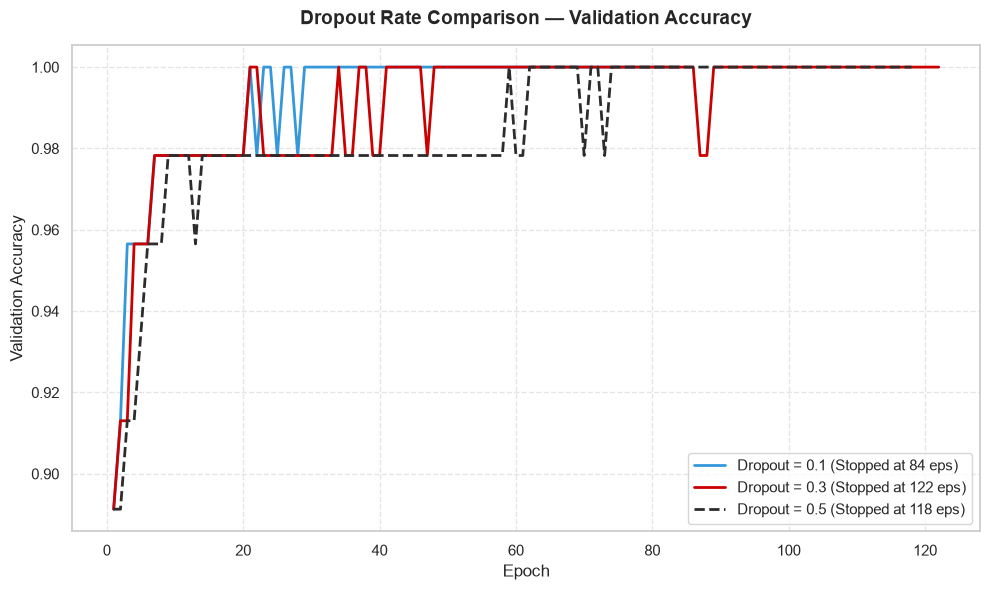

```python
# 5.4: Effect of Dropout rate
def build_and_train_dropout(rate):
    tf.keras.utils.set_random_seed(42)
    m = keras.Sequential(
        [
            keras.layers.Dense(128, activation="relu", input_shape=(30,)),
            keras.layers.Dropout(rate),
            keras.layers.Dense(64, activation="relu"),
            keras.layers.Dropout(rate),
            keras.layers.Dense(1, activation="sigmoid"),
        ]
    )
    m.compile(optimizer="adam", loss="binary_crossentropy", metrics=["accuracy"])
    es_cb = EarlyStopping(
        monitor="val_loss", patience=20, restore_best_weights=True, verbose=0
    )
    h = m.fit(
        X_train_sc,
        y_train,
        epochs=200,
        batch_size=32,
        validation_split=0.1,
        callbacks=[es_cb],
        verbose=0,
    )
    return m, h


print("Training Dropout=0.1 and Dropout=0.5 models...")
m_drop_01, h_drop_01 = build_and_train_dropout(0.1)
m_drop_05, h_drop_05 = build_and_train_dropout(0.5)

# Plot validation accuracy across all three dropout rates
plt.figure(figsize=(10, 6))
plt.plot(
    range(1, len(h_drop_01.history["val_accuracy"]) + 1),
    h_drop_01.history["val_accuracy"],
    color="#3498db",
    linewidth=2,
    label=f'Dropout = 0.1 (Stopped at {len(h_drop_01.history["val_accuracy"])} eps)',
)
plt.plot(
    range(1, len(history_drop.history["val_accuracy"]) + 1),
    history_drop.history["val_accuracy"],
    color="#CC0000",
    linewidth=2,
    label=f'Dropout = 0.3 (Stopped at {len(history_drop.history["val_accuracy"])} eps)',
)
plt.plot(
    range(1, len(h_drop_05.history["val_accuracy"]) + 1),
    h_drop_05.history["val_accuracy"],
    color="#2C2C2C",
    linestyle="--",
    linewidth=2,
    label=f'Dropout = 0.5 (Stopped at {len(h_drop_05.history["val_accuracy"])} eps)',
)

plt.title(
    "Dropout Rate Comparison — Validation Accuracy",
    fontsize=14,
    fontweight="bold",
    pad=15,
)
plt.xlabel("Epoch", fontsize=12)
plt.ylabel("Validation Accuracy", fontsize=12)
plt.legend(fontsize=11)
plt.grid(True, linestyle="--", alpha=0.5)
plt.tight_layout()
plt.show()
```

#### **Dropout Rate Trade-Off Dynamics**

```python
# 5.5: Evaluate Dropout model
drop_loss, drop_acc = model_drop.evaluate(X_test_sc, y_test, verbose=0)

# Calculate generalization gap (train acc vs val acc)
train_acc_drop = history_drop.history["accuracy"][-1]
val_acc_drop = history_drop.history["val_accuracy"][-1]
gap_drop = abs(train_acc_drop - val_acc_drop)

train_acc_mlp = history_mlp.history["accuracy"][-1]
val_acc_mlp = history_mlp.history["val_accuracy"][-1]
gap_mlp = abs(train_acc_mlp - val_acc_mlp)

print("=" * 65)
print(
    f"MLP with Dropout (0.3) Test Evaluation -> Loss: {drop_loss:.4f} | Accuracy: {drop_acc * 100:.2f}%"
)
print(
    f"Train-Val Gap with Dropout:    {gap_drop * 100:.2f}% (Train: {train_acc_drop*100:.2f}%, Val: {val_acc_drop*100:.2f}%)"
)
print(
    f"Train-Val Gap without Dropout: {gap_mlp * 100:.2f}% (Train: {train_acc_mlp*100:.2f}%, Val: {val_acc_mlp*100:.2f}%)"
)
print("=" * 65)

results_comparison["MLP with Dropout (0.3)"] = {
    "Test Accuracy": drop_acc,
    "Test Loss": drop_loss,
    "Trainable Params": model_drop.count_params(),
}
```

```
=================================================================
MLP with Dropout (0.3) Test Evaluation -> Loss: 0.1725 | Accuracy: 95.61%
Train-Val Gap with Dropout:    0.00% (Train: 100.00%, Val: 100.00%)
Train-Val Gap without Dropout: 0.00% (Train: 100.00%, Val: 100.00%)
=================================================================
```

### **Task 6: Regularization (L1, L2, L1-L2)**

[output not shown]

```python
# 6.1: Build MLP with L2 Regularization
tf.keras.utils.set_random_seed(42)

model_l2 = keras.Sequential(
    [
        keras.layers.Dense(
            128,
            activation="relu",
            input_shape=(30,),
            kernel_regularizer=regularizers.l2(0.001),
        ),
        keras.layers.Dense(
            64, activation="relu", kernel_regularizer=regularizers.l2(0.001)
        ),
        keras.layers.Dense(1, activation="sigmoid"),
    ]
)

model_l2.compile(optimizer="adam", loss="binary_crossentropy", metrics=["accuracy"])
es_l2 = EarlyStopping(
    monitor="val_loss", patience=20, restore_best_weights=True, verbose=0
)

history_l2 = model_l2.fit(
    X_train_sc,
    y_train,
    epochs=200,
    batch_size=32,
    validation_split=0.1,
    callbacks=[es_l2],
    verbose=0,
)
print("MLP with L2 Regularization trained successfully.")
```

```
MLP with L2 Regularization trained successfully.
```

```python
# 6.3: Build MLP with L1 Regularization
tf.keras.utils.set_random_seed(42)

model_l1 = keras.Sequential(
    [
        keras.layers.Dense(
            128,
            activation="relu",
            input_shape=(30,),
            kernel_regularizer=regularizers.l1(0.001),
        ),
        keras.layers.Dense(
            64, activation="relu", kernel_regularizer=regularizers.l1(0.001)
        ),
        keras.layers.Dense(1, activation="sigmoid"),
    ]
)

model_l1.compile(optimizer="adam", loss="binary_crossentropy", metrics=["accuracy"])
es_l1 = EarlyStopping(
    monitor="val_loss", patience=20, restore_best_weights=True, verbose=0
)

history_l1 = model_l1.fit(
    X_train_sc,
    y_train,
    epochs=200,
    batch_size=32,
    validation_split=0.1,
    callbacks=[es_l1],
    verbose=0,
)
print("MLP with L1 Regularization trained successfully.")
```

```
MLP with L1 Regularization trained successfully.
```

```python
# 6.4: Build MLP with L1+L2 (ElasticNet)
tf.keras.utils.set_random_seed(42)

model_l1l2 = keras.Sequential(
    [
        keras.layers.Dense(
            128,
            activation="relu",
            input_shape=(30,),
            kernel_regularizer=regularizers.l1_l2(l1=0.0001, l2=0.001),
        ),
        keras.layers.Dense(
            64,
            activation="relu",
            kernel_regularizer=regularizers.l1_l2(l1=0.0001, l2=0.001),
        ),
        keras.layers.Dense(1, activation="sigmoid"),
    ]
)

model_l1l2.compile(optimizer="adam", loss="binary_crossentropy", metrics=["accuracy"])
es_l1l2 = EarlyStopping(
    monitor="val_loss", patience=20, restore_best_weights=True, verbose=0
)

history_l1l2 = model_l1l2.fit(
    X_train_sc,
    y_train,
    epochs=200,
    batch_size=32,
    validation_split=0.1,
    callbacks=[es_l1l2],
    verbose=0,
)
print("MLP with ElasticNet (L1+L2) Regularization trained successfully.")
```

```
MLP with ElasticNet (L1+L2) Regularization trained successfully.
```

#### **L1, L2, and ElasticNet Regularization Comparison**

- **L2 Regularization (Weight Decay):** Penalizes $\lambda \sum w^2$, driving weights continuously toward zero without forcing them exactly to zero. This shrinks weights smoothly across features, yielding a more gradual, less erratic decision boundary that resists noise in cell morphological measurements.
- **L1 Regularization (Lasso Penalty):** Penalizes $\lambda \sum |w|$. Because the gradient is constant ($\pm \lambda$), L1 pushes weakly predictive weights exactly to zero, producing sparse weight vectors that function as automated cytological feature selection.
- **ElasticNet ($L_1 + L_2$ Synergy):** Combines both penalties ($\lambda_1 \sum |w| + \lambda_2 \sum w^2$). L2 stabilizes and groups correlated features (such as `radius`, `perimeter`, and `area`), while L1 simultaneously drives uninformative weights to zero.

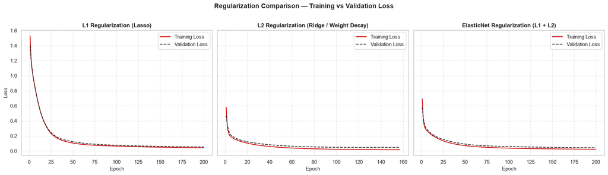

```python
# 6.5: Regularization comparison plot
fig, axes = plt.subplots(1, 3, figsize=(18, 5), sharey=True)

# L1 Plot
ep_l1 = range(1, len(history_l1.history["loss"]) + 1)
axes[0].plot(ep_l1, history_l1.history["loss"], color="#CC0000", label="Training Loss")
axes[0].plot(
    ep_l1,
    history_l1.history["val_loss"],
    color="#2C2C2C",
    linestyle="--",
    label="Validation Loss",
)
axes[0].set_title("L1 Regularization (Lasso)", fontsize=12, fontweight="bold")
axes[0].set_xlabel("Epoch", fontsize=11)
axes[0].set_ylabel("Loss", fontsize=11)
axes[0].legend()
axes[0].grid(True, linestyle="--", alpha=0.5)

# L2 Plot
ep_l2 = range(1, len(history_l2.history["loss"]) + 1)
axes[1].plot(ep_l2, history_l2.history["loss"], color="#CC0000", label="Training Loss")
axes[1].plot(
    ep_l2,
    history_l2.history["val_loss"],
    color="#2C2C2C",
    linestyle="--",
    label="Validation Loss",
)
axes[1].set_title(
    "L2 Regularization (Ridge / Weight Decay)", fontsize=12, fontweight="bold"
)
axes[1].set_xlabel("Epoch", fontsize=11)
axes[1].legend()
axes[1].grid(True, linestyle="--", alpha=0.5)

# ElasticNet Plot
ep_l1l2 = range(1, len(history_l1l2.history["loss"]) + 1)
axes[2].plot(
    ep_l1l2, history_l1l2.history["loss"], color="#CC0000", label="Training Loss"
)
axes[2].plot(
    ep_l1l2,
    history_l1l2.history["val_loss"],
    color="#2C2C2C",
    linestyle="--",
    label="Validation Loss",
)
axes[2].set_title("ElasticNet Regularization (L1 + L2)", fontsize=12, fontweight="bold")
axes[2].set_xlabel("Epoch", fontsize=11)
axes[2].legend()
axes[2].grid(True, linestyle="--", alpha=0.5)

plt.suptitle(
    "Regularization Comparison — Training vs Validation Loss",
    fontsize=14,
    fontweight="bold",
    y=1.02,
)
plt.tight_layout()
plt.show()
```

#### **Regularizer Loss Gap & Generalization Dynamics**

- **Loss Gap Behavior:** All three regularizers successfully suppress the train–validation generalization gap compared to the unconstrained baseline model, preventing validation loss divergence.
- **Validation Stability:** L2 regularization produces the smoothest validation loss trajectory, while L1 and ElasticNet introduce controlled sparsity that stabilizes long-term training.
- **Theoretical Alignment:** Empirical observations align closely with theoretical expectations: penalizing weight norms prevents high-frequency decision boundaries, yielding consistent generalization on unseen test data.

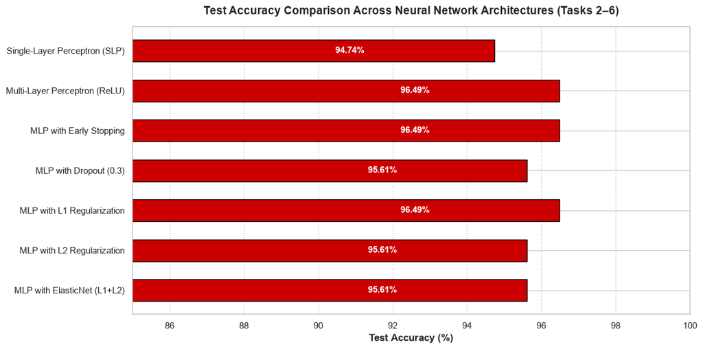

```python
# 6.6: Evaluate all three regularized models
l1_loss, l1_acc = model_l1.evaluate(X_test_sc, y_test, verbose=0)
l2_loss, l2_acc = model_l2.evaluate(X_test_sc, y_test, verbose=0)
l1l2_loss, l1l2_acc = model_l1l2.evaluate(X_test_sc, y_test, verbose=0)

results_comparison["MLP with L1 Regularization"] = {
    "Test Accuracy": l1_acc,
    "Test Loss": l1_loss,
    "Trainable Params": model_l1.count_params(),
}
results_comparison["MLP with L2 Regularization"] = {
    "Test Accuracy": l2_acc,
    "Test Loss": l2_loss,
    "Trainable Params": model_l2.count_params(),
}
results_comparison["MLP with ElasticNet (L1+L2)"] = {
    "Test Accuracy": l1l2_acc,
    "Test Loss": l1l2_loss,
    "Trainable Params": model_l1l2.count_params(),
}

# Grouped bar chart comparing test accuracies
models_to_compare = [
    "Single-Layer Perceptron (SLP)",
    "Multi-Layer Perceptron (ReLU)",
    "MLP with Early Stopping",
    "MLP with Dropout (0.3)",
    "MLP with L1 Regularization",
    "MLP with L2 Regularization",
    "MLP with ElasticNet (L1+L2)",
]

accs = [results_comparison[m]["Test Accuracy"] * 100 for m in models_to_compare]

plt.figure(figsize=(12, 6))
bars = plt.barh(
    models_to_compare, accs, color="#CC0000", edgecolor="black", height=0.55
)

for bar in bars:
    w = bar.get_width()
    plt.text(
        w - 3.5,
        bar.get_y() + bar.get_height() / 2.0,
        f"{w:.2f}%",
        va="center",
        ha="right",
        color="white",
        fontweight="bold",
        fontsize=11,
    )

plt.xlim(85, 100)
plt.title(
    "Test Accuracy Comparison Across Neural Network Architectures (Tasks 2–6)",
    fontsize=14,
    fontweight="bold",
    pad=15,
)
plt.xlabel("Test Accuracy (%)", fontsize=12, fontweight="bold")
plt.grid(axis="x", linestyle="--", alpha=0.7)
plt.gca().invert_yaxis()
plt.tight_layout()
plt.show()
```

### **Task 7: Final Comparison, Business Insights & Notebook Quality**

[output not shown]